# CDA_Project

24341638-Kenrick LIM

2024-09-21

## Youtube Link

https://youtu.be/k6_FzlGZWls

```r
Countriesdeath<-read.csv("Countries and death causes.csv",sep=",",header=TRUE)
pop<-read.csv("API_SP.POP.TOTL_DS2_en_csv_v2_31753.csv",sep=",",header=TRUE,skip = 4)
GDP<-read.csv("API_NY.GDP.PCAP.CD_DS2_en_csv_v2_31681.csv",sep=",",header=TRUE,skip = 4)
```

Above is the line of code that reads the data file required to conduct the analysis which contains the countries death , GDP and the population

# Exploratory Data Analysis(EDA):

In here, we wil explore the data that we are going to use in this Project. We can use summary(), str(), View() and etc to see what is happening to the data

```r
summary(Countriesdeath)
```

```
##     Entity              Code                Year      Outdoor.air.pollution
##  Length:6840        Length:6840        Min.   :1990   Min.   :      0
##  Class :character   Class :character   1st Qu.:1997   1st Qu.:    434
##  Mode  :character   Mode  :character   Median :2004   Median :   2101
##                                        Mean   :2004   Mean   :  84582
##                                        3rd Qu.:2012   3rd Qu.:  11810
##                                        Max.   :2019   Max.   :4506193
##  High.systolic.blood.pressure Diet.high.in.sodium Diet.low.in.whole.grains
##  Min.   :       2             Min.   :      0.0   Min.   :      0.0
##  1st Qu.:    1828             1st Qu.:    137.0   1st Qu.:    273.8
##  Median :    8770             Median :    969.5   Median :   1444.0
##  Mean   :  224225             Mean   :  40497.2   Mean   :  38691.3
##  3rd Qu.:   40356             3rd Qu.:   5169.8   3rd Qu.:   6773.2
##  Max.   :10845595             Max.   :1885356.0   Max.   :1844836.0
##   Alochol.use        Diet.low.in.fruits  Unsafe.water.source Secondhand.smoke
##  Min.   :      0.0   Min.   :      0.0   Min.   :      0.0   Min.   :      1
##  1st Qu.:    263.8   1st Qu.:    144.0   1st Qu.:      7.0   1st Qu.:    209
##  Median :   1780.5   Median :    834.5   Median :    182.5   Median :    994
##  Mean   :  54848.6   Mean   :  23957.8   Mean   :  44086.4   Mean   :  30364
##  3rd Qu.:   8368.0   3rd Qu.:   3104.8   3rd Qu.:   5599.2   3rd Qu.:   4348
##  Max.   :2441973.0   Max.   :1046015.0   Max.   :2450944.0   Max.   :1304318
##  Low.birth.weight  Child.wasting       Unsafe.sex
##  Min.   :      0   Min.   :      0   Min.   :      0
##  1st Qu.:    123   1st Qu.:     26   1st Qu.:     97
##  Median :   1057   Median :    504   Median :    619
##  Mean   :  59126   Mean   :  49924   Mean   :  27646
##  3rd Qu.:  10903   3rd Qu.:   9765   3rd Qu.:   4492
##  Max.   :3033425   Max.   :3430422   Max.   :1664813
##  Diet.low.in.nuts.and.seeds Household.air.pollution.from.solid.fuels
##  Min.   :     0             Min.   :      0
##  1st Qu.:    27             1st Qu.:     32
##  Median :   252             Median :    821
##  Mean   : 12996             Mean   :  83641
##  3rd Qu.:  1998             3rd Qu.:  10870
##  Max.   :575139             Max.   :4358214
##  Diet.low.in.Vegetables Low.physical.activity    Smoking
##  Min.   :     0.0       Min.   :     0.0      Min.   :      1
##  1st Qu.:   109.0       1st Qu.:    92.0      1st Qu.:    894
##  Median :   590.5       Median :   521.5      Median :   4987
##  Mean   : 11982.5       Mean   : 16489.1      Mean   : 181958
```

[output cut: 15 more lines]

```
##  Max.   :1842275   Max.   :1200349                   Max.   :494492
##  Low.bone.mineral.density Vitamin.A.deficiency Child.stunting
##  Min.   :     0           Min.   :     0.0     Min.   :     0.0
##  1st Qu.:    43           1st Qu.:     0.0     1st Qu.:     1.0
##  Median :   277           Median :     2.0     Median :    41.5
##  Mean   :  8182           Mean   :  2471.6     Mean   : 11164.3
##  3rd Qu.:  1232           3rd Qu.:   230.2     3rd Qu.:  1563.2
##  Max.   :437884           Max.   :207555.0     Max.   :833449.0
##  Discontinued.breastfeeding Non.exclusive.breastfeeding Iron.deficiency
##  Min.   :    0.00           Min.   :     0.0            Min.   :    0
##  1st Qu.:    0.00           1st Qu.:     3.0            1st Qu.:    1
##  Median :    4.00           Median :    60.5            Median :   12
##  Mean   :  431.46           Mean   :  7171.9            Mean   : 1421
##  3rd Qu.:   71.25           3rd Qu.:  1315.5            3rd Qu.:  238
##  Max.   :33106.00           Max.   :505470.0            Max.   :73461
```

```r
str(Countriesdeath)
```

```
## 'data.frame':    6840 obs. of  31 variables:
##  $ Entity                                  : chr  "Afghanistan" "Afghanistan" "Afghanistan" "Afghanistan" ...
##  $ Code                                    : chr  "AFG" "AFG" "AFG" "AFG" ...
##  $ Year                                    : int  1990 1991 1992 1993 1994 1995 1996 1997 1998 1999 ...
##  $ Outdoor.air.pollution                   : int  3169 3222 3395 3623 3788 3869 3943 4024 4040 4042 ...
##  $ High.systolic.blood.pressure            : int  25633 25872 26309 26961 27658 28090 28587 29021 29349 29712 ...
##  $ Diet.high.in.sodium                     : int  1045 1055 1075 1103 1134 1154 1178 1202 1222 1242 ...
##  $ Diet.low.in.whole.grains                : int  7077 7149 7297 7499 7698 7807 7943 8075 8173 8265 ...
##  $ Alochol.use                             : int  356 364 376 389 399 406 413 420 425 426 ...
##  $ Diet.low.in.fruits                      : int  3185 3248 3351 3480 3610 3703 3819 3938 4038 4127 ...
##  $ Unsafe.water.source                     : int  3702 4309 5356 7152 7192 8378 8487 9348 9788 9931 ...
##  $ Secondhand.smoke                        : int  4794 4921 5279 5734 6050 6167 6298 6425 6402 6323 ...
##  $ Low.birth.weight                        : int  16135 17924 21200 23795 24866 25534 25997 26246 25805 25080 ...
##  $ Child.wasting                           : int  19546 20334 22895 27002 29205 30943 31628 32736 32760 32271 ...
##  $ Unsafe.sex                              : int  351 361 378 395 410 422 435 448 458 469 ...
```

[output cut: 17 more lines]

```r
View(Countriesdeath)
summary(GDP)
```

```
##  Country.Name       Country.Code       Indicator.Name     Indicator.Code
##  Length:266         Length:266         Length:266         Length:266
##  Class :character   Class :character   Class :character   Class :character
##  Mode  :character   Mode  :character   Mode  :character   Mode  :character
##
##
##
##
##      X1960            X1961             X1962             X1963
##  Min.   :  25.1   Min.   :  27.27   Min.   :  27.95   Min.   :  25.81
##  1st Qu.: 116.3   1st Qu.: 121.19   1st Qu.: 126.23   1st Qu.: 130.84
##  Median : 217.6   Median : 202.92   Median : 206.58   Median : 218.86
##  Mean   : 489.3   Mean   : 505.31   Mean   : 556.33   Mean   : 588.84
##  3rd Qu.: 507.7   3rd Qu.: 571.43   3rd Qu.: 628.69   3rd Qu.: 632.28
##  Max.   :2999.9   Max.   :3059.16   Max.   :4833.83   Max.   :4520.62
##  NA's   :128      NA's   :124       NA's   :122       NA's   :122
##      X1964             X1965             X1966             X1967
##  Min.   :  17.33   Min.   :  15.11   Min.   :  11.79   Min.   :  16.52
##  1st Qu.: 138.25   1st Qu.: 146.09   1st Qu.: 155.36   1st Qu.: 156.71
##  Median : 237.91   Median : 264.11   Median : 267.33   Median : 273.87
##  Mean   : 638.10   Mean   : 681.93   Mean   : 726.14   Mean   : 745.96
##  3rd Qu.: 752.06   3rd Qu.: 851.92   3rd Qu.: 896.74   3rd Qu.: 870.34
##  Max.   :4448.05   Max.   :4081.42   Max.   :4228.74   Max.   :4325.96
##  NA's   :122       NA's   :112       NA's   :111       NA's   :108
##      X1968            X1969             X1970              X1971
##  Min.   :  21.5   Min.   :  21.45   Min.   :   20.66   Min.   :   21.04
##  1st Qu.: 163.4   1st Qu.: 169.63   1st Qu.:  205.22   1st Qu.:  209.13
##  Median : 294.8   Median : 297.20   Median :  349.02   Median :  375.48
##  Mean   : 777.8   Mean   : 842.12   Mean   : 1015.76   Mean   : 1117.18
##  3rd Qu.: 876.9   3rd Qu.: 910.65   3rd Qu.: 1342.99   3rd Qu.: 1408.89
##  Max.   :4684.6   Max.   :5020.00   Max.   :12077.76   Max.   :13315.98
##  NA's   :107      NA's   :107       NA's   :85         NA's   :84
##      X1972              X1973              X1974              X1975
##  Min.   :   23.19   Min.   :   24.68   Min.   :   41.19   Min.   :   34.97
##  1st Qu.:  226.59   1st Qu.:  273.43   1st Qu.:  327.32   1st Qu.:  362.90
##  Median :  420.81   Median :  538.96   Median :  694.98   Median :  719.72
##  Mean   : 1298.34   Mean   : 1650.70   Mean   : 2148.70   Mean   : 2325.55
##  3rd Qu.: 1810.38   3rd Qu.: 2307.85   3rd Qu.: 2613.70   3rd Qu.: 2968.36
##  Max.   :16169.87   Max.   :20857.06   Max.   :23684.09   Max.   :27894.49
##  NA's   :84         NA's   :84         NA's   :84         NA's   :80
```

[output cut: 81 more lines]

```
##  Min.   :   242.5   Min.   :   244.2   Min.   :   232.1   Min.   :   217
##  1st Qu.:  2019.3   1st Qu.:  2041.9   1st Qu.:  2202.3   1st Qu.:  2180
##  Median :  6014.6   Median :  6395.7   Median :  6847.1   Median :  6838
##  Mean   : 15753.1   Mean   : 16555.2   Mean   : 17539.9   Mean   : 17436
##  3rd Qu.: 18688.8   3rd Qu.: 20264.3   3rd Qu.: 22059.0   3rd Qu.: 21656
##  Max.   :174412.5   Max.   :173611.7   Max.   :193968.1   Max.   :199383
##  NA's   :8          NA's   :8          NA's   :8          NA's   :7
##      X2020              X2021              X2022            X2023
##  Min.   :   216.8   Min.   :   221.2   Min.   :   259   Min.   :   199.6
##  1st Qu.:  2094.8   1st Qu.:  2350.4   1st Qu.:  2376   1st Qu.:  2308.7
##  Median :  6192.2   Median :  7237.3   Median :  7588   Median :  7289.9
##  Mean   : 16212.2   Mean   : 18647.6   Mean   : 18791   Mean   : 16416.7
##  3rd Qu.: 19027.6   3rd Qu.: 21765.7   3rd Qu.: 21073   3rd Qu.: 22138.6
##  Max.   :182537.4   Max.   :235132.8   Max.   :240862   Max.   :128259.4
##  NA's   :8          NA's   :9          NA's   :15       NA's   :32
```

```r
str(GDP)
```

```
## 'data.frame':    266 obs. of  68 variables:
##  $ Country.Name  : chr  "Aruba" "Africa Eastern and Southern" "Afghanistan" "Africa Western and Central" ...
##  $ Country.Code  : chr  "ABW" "AFE" "AFG" "AFW" ...
##  $ Indicator.Name: chr  "GDP per capita (current US$)" "GDP per capita (current US$)" "GDP per capita (current US$)" "GDP per capita (current US$)" ...
##  $ Indicator.Code: chr  "NY.GDP.PCAP.CD" "NY.GDP.PCAP.CD" "NY.GDP.PCAP.CD" "NY.GDP.PCAP.CD" ...
##  $ X1960         : num  NA 162 NA 122 NA ...
##  $ X1961         : num  NA 166 NA 128 NA ...
##  $ X1962         : num  NA 172 NA 134 NA ...
##  $ X1963         : num  NA 182 NA 139 NA ...
##  $ X1964         : num  NA 193 NA 149 NA ...
##  $ X1965         : num  NA 203 NA 156 NA ...
##  $ X1966         : num  NA 215 NA 163 NA ...
##  $ X1967         : num  NA 227 NA 146 NA ...
##  $ X1968         : num  NA 238 NA 147 NA ...
##  $ X1969         : num  NA 256 NA 163 NA ...
```

[output cut: 54 more lines]

```r
View(GDP)
summary(pop)
```

```
##  Country.Name       Country.Code       Indicator.Name     Indicator.Code
##  Length:266         Length:266         Length:266         Length:266
##  Class :character   Class :character   Class :character   Class :character
##  Mode  :character   Mode  :character   Mode  :character   Mode  :character
##
##
##
##
##      X1960               X1961               X1962
##  Min.   :2.646e+03   Min.   :2.888e+03   Min.   :3.171e+03
##  1st Qu.:5.132e+05   1st Qu.:5.231e+05   1st Qu.:5.338e+05
##  Median :3.708e+06   Median :3.817e+06   Median :3.931e+06
##  Mean   :1.158e+08   Mean   :1.174e+08   Mean   :1.195e+08
##  3rd Qu.:2.671e+07   3rd Qu.:2.749e+07   3rd Qu.:2.830e+07
##  Max.   :3.032e+09   Max.   :3.072e+09   Max.   :3.127e+09
##  NA's   :2           NA's   :2           NA's   :2
##      X1963               X1964               X1965
##  Min.   :3.481e+03   Min.   :3.811e+03   Min.   :4.161e+03
##  1st Qu.:5.449e+05   1st Qu.:5.567e+05   1st Qu.:5.651e+05
##  Median :4.034e+06   Median :4.113e+06   Median :4.195e+06
##  Mean   :1.222e+08   Mean   :1.249e+08   Mean   :1.276e+08
##  3rd Qu.:2.915e+07   3rd Qu.:3.002e+07   3rd Qu.:3.085e+07
##  Max.   :3.193e+09   Max.   :3.260e+09   Max.   :3.328e+09
##  NA's   :2           NA's   :2           NA's   :2
##      X1966               X1967               X1968
##  Min.   :4.531e+03   Min.   :4.930e+03   Min.   :5.354e+03
##  1st Qu.:5.691e+05   1st Qu.:5.774e+05   1st Qu.:5.833e+05
##  Median :4.257e+06   Median :4.317e+06   Median :4.411e+06
##  Mean   :1.305e+08   Mean   :1.333e+08   Mean   :1.362e+08
##  3rd Qu.:3.163e+07   3rd Qu.:3.209e+07   3rd Qu.:3.250e+07
##  Max.   :3.399e+09   Max.   :3.468e+09   Max.   :3.540e+09
##  NA's   :2           NA's   :2           NA's   :2
##      X1969               X1970               X1971
##  Min.   :5.646e+03   Min.   :5.665e+03   Min.   :5.742e+03
##  1st Qu.:5.876e+05   1st Qu.:5.960e+05   1st Qu.:6.083e+05
##  Median :4.516e+06   Median :4.596e+06   Median :4.650e+06
##  Mean   :1.393e+08   Mean   :1.424e+08   Mean   :1.455e+08
##  3rd Qu.:3.277e+07   3rd Qu.:3.295e+07   3rd Qu.:3.322e+07
##  Max.   :3.615e+09   Max.   :3.690e+09   Max.   :3.768e+09
##  NA's   :2           NA's   :2           NA's   :2
```

[output cut: 129 more lines]

```
##  Min.   :1.107e+04   Min.   :1.120e+04   Min.   :1.131e+04
##  1st Qu.:1.790e+06   1st Qu.:1.786e+06   1st Qu.:1.768e+06
##  Median :1.061e+07   Median :1.051e+07   Median :1.049e+07
##  Mean   :3.174e+08   Mean   :3.207e+08   Mean   :3.236e+08
##  3rd Qu.:6.170e+07   3rd Qu.:6.359e+07   3rd Qu.:6.550e+07
##  Max.   :7.821e+09   Max.   :7.889e+09   Max.   :7.952e+09
##  NA's   :1           NA's   :1           NA's   :1
##      X2023
##  Min.   :1.140e+04
##  1st Qu.:1.756e+06
##  Median :1.059e+07
##  Mean   :3.270e+08
##  3rd Qu.:6.744e+07
##  Max.   :8.025e+09
##  NA's   :1
```

```r
str(pop)
```

```
## 'data.frame':    266 obs. of  68 variables:
##  $ Country.Name  : chr  "Aruba" "Africa Eastern and Southern" "Afghanistan" "Africa Western and Central" ...
##  $ Country.Code  : chr  "ABW" "AFE" "AFG" "AFW" ...
##  $ Indicator.Name: chr  "Population, total" "Population, total" "Population, total" "Population, total" ...
##  $ Indicator.Code: chr  "SP.POP.TOTL" "SP.POP.TOTL" "SP.POP.TOTL" "SP.POP.TOTL" ...
##  $ X1960         : num  5.46e+04 1.31e+08 8.62e+06 9.73e+07 5.36e+06 ...
##  $ X1961         : num  5.58e+04 1.34e+08 8.79e+06 9.93e+07 5.44e+06 ...
##  $ X1962         : num  5.67e+04 1.38e+08 8.97e+06 1.01e+08 5.52e+06 ...
##  $ X1963         : num  5.75e+04 1.42e+08 9.16e+06 1.04e+08 5.60e+06 ...
##  $ X1964         : num  5.82e+04 1.46e+08 9.36e+06 1.06e+08 5.67e+06 ...
##  $ X1965         : num  5.88e+04 1.50e+08 9.57e+06 1.08e+08 5.74e+06 ...
##  $ X1966         : num  5.93e+04 1.54e+08 9.78e+06 1.11e+08 5.79e+06 ...
##  $ X1967         : num  5.95e+04 1.58e+08 1.00e+07 1.13e+08 5.83e+06 ...
##  $ X1968         : num  5.95e+04 1.63e+08 1.02e+07 1.16e+08 5.87e+06 ...
##  $ X1969         : num  5.93e+04 1.68e+08 1.05e+07 1.19e+08 5.93e+06 ...
```

[output cut: 54 more lines]

```r
View(pop)
```

In here, The use of summary(),str(),View() is to provide the data type , summary and the contents of the data which can be useful to check any NA and guiding us for doing data cleaning and EDA.Turns out there are no missing values in the Countries and death data whereas in both GDP and Population had those but GDP has the most one.

```r
Countriesdeath_modify<-Countriesdeath
GDPS<-GDP
pops<-pop
```

Then, we are trying to duplicate the data for countries/death, gdp and population and the purpose is to keep the original data because if we use the original data to merge and do transformation we cannot refer back to the original data since we already use it.

# Data Cleaning and Transformation

```r
library(tidyr)
library(dplyr)
# Reshape the GDP dataset from wide to long format
GDPS <- GDPS %>%
  pivot_longer(cols = starts_with("X"),  # Select columns that start with 'X' (e.g., X1960, X1961...)
               names_to = "Year",        # New column for the years
               names_prefix = "X",       # Remove the 'X' from the year column names
               values_to = "GDP_per_capita")  # Name of the new column for GDP values

# Convert 'Year' from character to numeric
GDPS$Year <- as.numeric(GDPS$Year)

# View the reshaped GDP dataset
head(GDPS)
```

```
## # A tibble: 6 × 6
##   Country.Name Country.Code Indicator.Name   Indicator.Code  Year GDP_per_capita
##   <chr>        <chr>        <chr>            <chr>          <dbl>          <dbl>
## 1 Aruba        ABW          GDP per capita … NY.GDP.PCAP.CD  1960             NA
## 2 Aruba        ABW          GDP per capita … NY.GDP.PCAP.CD  1961             NA
## 3 Aruba        ABW          GDP per capita … NY.GDP.PCAP.CD  1962             NA
## 4 Aruba        ABW          GDP per capita … NY.GDP.PCAP.CD  1963             NA
## 5 Aruba        ABW          GDP per capita … NY.GDP.PCAP.CD  1964             NA
## 6 Aruba        ABW          GDP per capita … NY.GDP.PCAP.CD  1965             NA
```

```r
# Reshape the Population dataset from wide to long format
population_long <- pops %>%
  pivot_longer(cols = starts_with("X"), names_to = "Year", values_to = "Population") %>%
  mutate(Year = as.numeric(sub("X", "", Year)))
# View the reshaped GDP dataset
population_long
```

```
## # A tibble: 17,024 × 6
##    Country.Name Country.Code Indicator.Name    Indicator.Code  Year Population
##    <chr>        <chr>        <chr>             <chr>          <dbl>      <dbl>
##  1 Aruba        ABW          Population, total SP.POP.TOTL     1960      54608
##  2 Aruba        ABW          Population, total SP.POP.TOTL     1961      55811
##  3 Aruba        ABW          Population, total SP.POP.TOTL     1962      56682
##  4 Aruba        ABW          Population, total SP.POP.TOTL     1963      57475
##  5 Aruba        ABW          Population, total SP.POP.TOTL     1964      58178
##  6 Aruba        ABW          Population, total SP.POP.TOTL     1965      58782
##  7 Aruba        ABW          Population, total SP.POP.TOTL     1966      59291
##  8 Aruba        ABW          Population, total SP.POP.TOTL     1967      59522
##  9 Aruba        ABW          Population, total SP.POP.TOTL     1968      59471
## 10 Aruba        ABW          Population, total SP.POP.TOTL     1969      59330
## # ℹ 17,014 more rows
```

After loading the dataset, we notice that GDP and population has the same data format and structure.Therefore, a conversion and adding year column since it is showing every single year in each column which is not practical as well as the value of GDP and Population.

```r
range(GDPS$Year)
```

```
## [1] 1960 2023
```

```r
range(population_long$Year)
```

```
## [1] 1960 2023
```

```r
range(Countriesdeath_modify$Year)
```

```
## [1] 1990 2019
```

Although, each dataset may contain years, However it is crucial to check the range since each dataset may have different range and this is important as well to determine the x and y for dataset when merging. These are the code check the range.

```r
# Rename columns to prepare for merging
colnames(GDPS)[colnames(GDPS) == "Country.Name"] <- "Country"
colnames(Countriesdeath_modify)[colnames(Countriesdeath_modify) == "Entity"] <- "Country"
colnames(GDPS)[colnames(GDPS) == "Country.Code"] <- "Country Code"
colnames(Countriesdeath_modify)[colnames(Countriesdeath_modify) == "Code"] <- "Country Code"
colnames(population_long)[colnames(population_long) == "Country.Name"] <- "Country"
colnames(population_long)[colnames(population_long) == "Country.Code"] <- "Country Code"
```

There is also renaming the column and the purpose of this is to had a same column name to prevent confusion of column names since these column will be the main purpose for merging between table.

```r
library(dplyr)
gdp_population_merged <- merge(
  GDPS %>% dplyr::select(Country, `Country Code`, Year, GDP_per_capita),
  population_long %>% dplyr::select(Country, `Country Code`, Year, Population),
  by = c("Country", "Country Code", "Year"))

gdp_population_merged2<-gdp_population_merged %>%
  filter(!(Year >= 1960 & Year <= 1989) & !(Year >= 2020 & Year <= 2023)) %>%
  dplyr::select(-Country)

unmatched_countries <- list()

# Loop through each country code in the GDP dataset
for (i in 1:nrow(gdp_population_merged2)) {

  # Find the matching row in the death causes dataset based on the Country.Code
  match_index <- which(Countriesdeath_modify$Country.Code == gdp_population_merged2$Country.Code[i])

  # If no match is found, store the country code in the unmatched list
  if (length(match_index) == 0) {
    unmatched_countries <- append(unmatched_countries, gdp_population_merged2$Country.Code[i])
  }
}

# Ensure correct selection and merge on shared columns
merged_data <- merge(Countriesdeath_modify, gdp_population_merged2, by = c("Country Code", "Year"),all = TRUE)
```

Here, the GDP and population data is merged and the next thing to do is omitting the rows that contain the given years.Notice the purpose of showing the range of years between dataset in the previous step.Also removing countries from the data since only Country Code and Year will be used during the merge with the Countries data. Since involivng Countries during the merge may cause missing data since there are countries with same Country code but having different name but still the same countries.

Finally, we then merge the dataset which will be used for further data cleaning.

```r
colSums(is.na(merged_data))
```

```
##                             Country Code
##                                        0
##                                     Year
##                                        0
##                                  Country
##                                     1980
##                    Outdoor.air.pollution
##                                     1980
##             High.systolic.blood.pressure
##                                     1980
##                      Diet.high.in.sodium
##                                     1980
##                 Diet.low.in.whole.grains
##                                     1980
##                              Alochol.use
##                                     1980
##                       Diet.low.in.fruits
##                                     1980
##                      Unsafe.water.source
##                                     1980
##                         Secondhand.smoke
##                                     1980
##                         Low.birth.weight
##                                     1980
##                            Child.wasting
##                                     1980
##                               Unsafe.sex
##                                     1980
##               Diet.low.in.nuts.and.seeds
##                                     1980
## Household.air.pollution.from.solid.fuels
##                                     1980
##                   Diet.low.in.Vegetables
##                                     1980
##                    Low.physical.activity
##                                     1980
##                                  Smoking
##                                     1980
##              High.fasting.plasma.glucose
##                                     1980
```

[output cut: 11 more lines]

```
##                                     1980
##                     Vitamin.A.deficiency
##                                     1980
##                           Child.stunting
##                                     1980
##               Discontinued.breastfeeding
##                                     1980
##              Non.exclusive.breastfeeding
##                                     1980
##                          Iron.deficiency
##                                     1980
##                           GDP_per_capita
##                                     1237
##                               Population
##                                      870
```

```r
sum(is.na(merged_data))
```

```
## [1] 59527
```

This code is to check if there is any missing values in the given merged data which can be helpful to detect which one we are focusing on imputation data .

```r
library(dplyr)

# Filter the dataframe for rows where the 'Country Code' is missing or empty
df_no_code <- merged_data %>%
  filter(is.na(`Country Code`) | `Country Code` == "") %>%
  distinct(Country)

# Display the distinct country names
print(df_no_code)
```

```
##                               Country
## 1        Western Pacific Region (WHO)
## 2                     South Asia (WB)
## 3                African Region (WHO)
## 4              World Bank High Income
## 5               World Bank Low Income
## 6        South-East Asia Region (WHO)
## 7      World Bank Upper Middle Income
## 8             Sub-Saharan Africa (WB)
## 9                            Scotland
## 10                                G20
## 11                            England
## 12     World Bank Lower Middle Income
## 13         Europe & Central Asia (WB)
## 14           East Asia & Pacific (WB)
## 15    Middle East & North Africa (WB)
## 16                     OECD Countries
## 17 Eastern Mediterranean Region (WHO)
## 18                   Northern Ireland
## 19     Latin America & Caribbean (WB)
## 20                              Wales
## 21                 North America (WB)
## 22              European Region (WHO)
## 23       Region of the Americas (WHO)
```

This code is to filter the countries from the merge dataset that does not contain Country Code or Missing and based on the output there are multiple organization,regions and economic groups which aggregate data as well as 4 parts of United Kingdom from multiple countries.

```r
# Filter countries that has no country code and excluding "World"
merged_data2 <- merged_data %>%
  filter(!is.na(`Country Code`) & `Country Code` != "" & Country != "World")
```

After identifying the countries without any country code. The next thing to do is to omit the rows which contains those including the 4 parts of UK since they don’t have GDP and Population whereas UK had.The code above executes them all.

```r
length(unique(merged_data2$Country))
```

```
## [1] 204
```

```r
library(dplyr)

non_countries <- c("American Samoa", "Bermuda", "Cook Islands", "Greenland",
                   "Guam", "Niue", "Northern Mariana Islands", "Puerto Rico",
                   "Tokelau", "United States Virgin Islands", "Palestine", "Taiwan")

# Step 2: Filter the dataset to omit non-country entities
cleaned_data <- merged_data2 %>%
  filter(!Country %in% non_countries)

# Impute missing values for Population and GDP_per_capita by using the median of each country
merged_data3 <- cleaned_data %>%
  group_by(Country) %>%
  mutate(
    Population = ifelse(is.na(Population), ifelse(all(is.na(Population)), 0, median(Population, na.rm = TRUE)), Population),
    GDP_per_capita = ifelse(is.na(GDP_per_capita), ifelse(all(is.na(GDP_per_capita)), 0, median(GDP_per_capita, na.rm = TRUE)), GDP_per_capita)
  ) %>%
  ungroup()  # Remove grouping to return the dataframe to normal
# Check if there are still any missing values
colSums(is.na(merged_data3))
```

```
##                             Country Code
##                                        0
##                                     Year
##                                        0
##                                  Country
##                                        0
##                    Outdoor.air.pollution
##                                        0
##             High.systolic.blood.pressure
##                                        0
##                      Diet.high.in.sodium
##                                        0
##                 Diet.low.in.whole.grains
##                                        0
##                              Alochol.use
##                                        0
##                       Diet.low.in.fruits
##                                        0
##                      Unsafe.water.source
##                                        0
##                         Secondhand.smoke
##                                        0
##                         Low.birth.weight
##                                        0
##                            Child.wasting
##                                        0
##                               Unsafe.sex
##                                        0
##               Diet.low.in.nuts.and.seeds
##                                        0
## Household.air.pollution.from.solid.fuels
##                                        0
##                   Diet.low.in.Vegetables
##                                        0
##                    Low.physical.activity
##                                        0
##                                  Smoking
##                                        0
##              High.fasting.plasma.glucose
##                                        0
```

[output cut: 11 more lines]

```
##                                        0
##                     Vitamin.A.deficiency
##                                        0
##                           Child.stunting
##                                        0
##               Discontinued.breastfeeding
##                                        0
##              Non.exclusive.breastfeeding
##                                        0
##                          Iron.deficiency
##                                        0
##                           GDP_per_capita
##                                        0
##                               Population
##                                        0
```

According to several sources, There are 12 countries that are not an actual countries from the dataset.The countries American Samoa ,Guam,Northern Mariana Islands, Puerto Rico, and United States Virgin Islands are US territories(List of Countries by Continent 2024, n.d.).Cook Islands and Niue are in free association of New Zealand (List of Countries by Continent 2024, n.d.). Bermuda is British Overseas territory (Heaton & Rushe, 2024).Tokelau is a dependent territory of New Zealand (Foster, 1998).Greenland is part of Kingdom of Denmark(List of Countries by Continent 2024, n.d.). Palestine is not fully independent state and Taiwan is part of China (List of Countries by Continent 2024, n.d.) .Which later will be ommited since part of this investigation will be focusing the death of each countries.

After omitting the non countries, we impute with median if there are existing values for population and GDP, otherwise set to 0 if all are missing and in the end check if there is any missing values just to be sure.

```r
#create a new column for Decision Tree called Death rate proxy and Class
merged_data3$Death_Rate_Proxy<-rowSums(merged_data3[,4:31],na.rm=TRUE)
#Create a new variable as the proportion of Death_Rate_Proxy over Population
merged_data3$Death_Proxy_Proportion <- merged_data3$Death_Rate_Proxy / merged_data3$Population

#calculate the median value from death rate proxy to create a class and convert them to factor
median_death<-median(merged_data3$Death_Proxy_Proportion,na.rm=TRUE)
merged_data3$Death_Rate_Class <- ifelse(merged_data3$Death_Proxy_Proportion > median_death, "High", "Low")
merged_data3$Death_Rate_Class <- as.factor(merged_data3$Death_Rate_Class)
levels(merged_data3$Death_Rate_Class)
```

```
## [1] "High" "Low"
```

```r
#to check if the feature engineer data has imbalance dataset
table(merged_data3$Death_Rate_Class)
```

```
##
## High  Low
## 2880 2880
```

This is to check if the dataset is imbalanced or not.

# Visualisation:

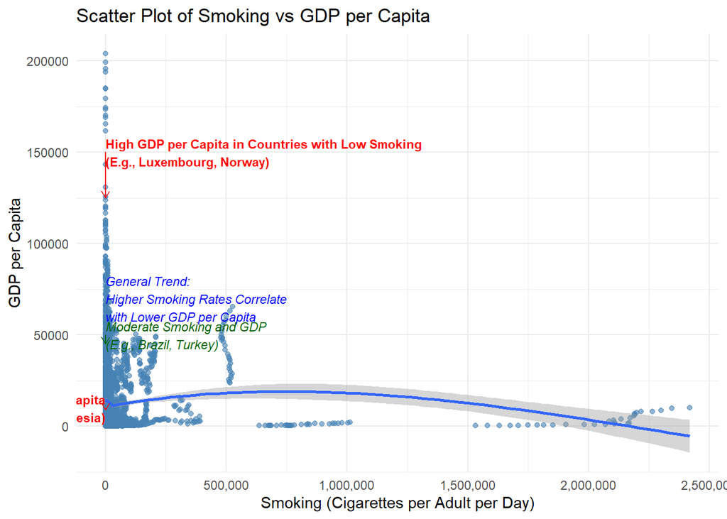

```r
#How GDP and population influence the prevalence of different causes of death in countries based on their death rate (High/Low).
library(ggplot2)
library(scales)
library(sf)
library(rnaturalearth)
library(rnaturalearthdata)
library(dplyr)
library(reshape2)
ggplot(merged_data3, aes(x = Smoking, y = GDP_per_capita)) +
  geom_point(alpha = 0.6, color = "steelblue") +
  geom_smooth() +
  labs(title = "Scatter Plot of Smoking vs GDP per Capita",
       x = "Smoking (Cigarettes per Adult per Day)",
       y = "GDP per Capita") +
  theme_minimal() +

  # Annotation for high GDP per capita outliers with low smoking rates
  annotate("text", x = 5, y = 150000, label = "High GDP per Capita in Countries with Low Smoking\n(E.g., Luxembourg, Norway)",
           size = 3, color = "red", fontface = "bold", hjust = 0) +
  annotate("segment", x = 5, xend = 6, y = 150000, yend = 125000,
           color = "red", arrow = arrow(length = unit(0.2, "cm"))) +

  # Annotation for large smoking rates and lower GDP per capita
  annotate("text", x = 20, y = 10000, label = "High Smoking with Lower GDP per Capita\n(E.g., Russia, Indonesia)",
           size = 3, color = "red", fontface = "bold", hjust = 1) +
  annotate("segment", x = 20, xend = 19, y = 10000, yend = 9000,
           color = "red", arrow = arrow(length = unit(0.2, "cm"))) +

  # Annotation for the general trend line
  annotate("text", x = 10, y = 70000, label = "General Trend:\nHigher Smoking Rates Correlate\nwith Lower GDP per Capita",
           size = 3, color = "blue", fontface = "italic", hjust = 0) +

  # Annotation for mid-level smoking rates and moderate GDP
  annotate("text", x = 12, y = 50000, label = "Moderate Smoking and GDP\n(E.g., Brazil, Turkey)",
           size = 3, color = "darkgreen", fontface = "italic", hjust = 0) +
  annotate("segment", x = 12, xend = 11, y = 50000, yend = 45000,
           color = "darkgreen", arrow = arrow(length = unit(0.2, "cm"))) +

  scale_x_continuous(labels = scales::comma)  # Format x-axis for readability
```

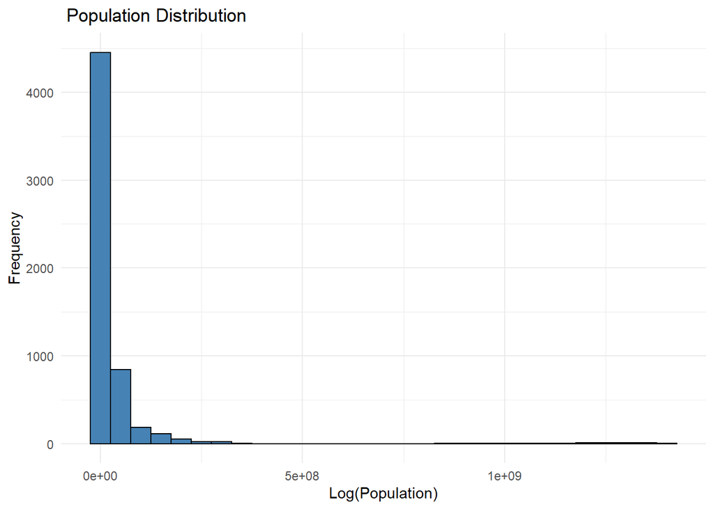

```r
#Histogram for Population
ggplot(merged_data3, aes(x = Population)) +
  geom_histogram(binwidth = 50000000, fill = "steelblue", color = "black") +
  labs(title = " Population Distribution",
       x = "Log(Population)",
       y = "Frequency") +
  theme_minimal()
```

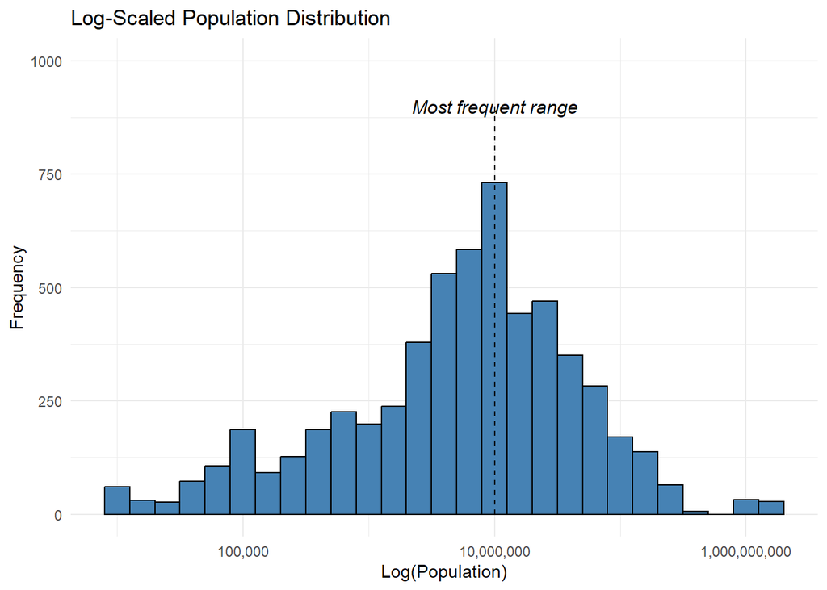

```r
#transformed
ggplot(merged_data3, aes(x = Population)) +
  geom_histogram(binwidth = 0.2, fill = "steelblue", color = "black") +
  labs(title = "Log-Scaled Population Distribution",
       x = "Log(Population)",
       y = "Frequency") +
  theme_minimal() +
  # Apply log scale transformation on x-axis
  scale_x_log10(labels = scales::comma) + # Log scale for x-axis and format numbers

  ylim(0, 1000) +  # Maximum frequency capped at 1000
  # Annotation for most frequent range in log scale
  annotate("text", x = 10^7, y = 900, label = "Most frequent range", color = "black", size = 4, fontface = "italic") +
  annotate("segment", x = 10^7, xend = 10^7, y = 0, yend = 900, color = "black", linetype = "dashed") # Dashed line at the frequent range
```

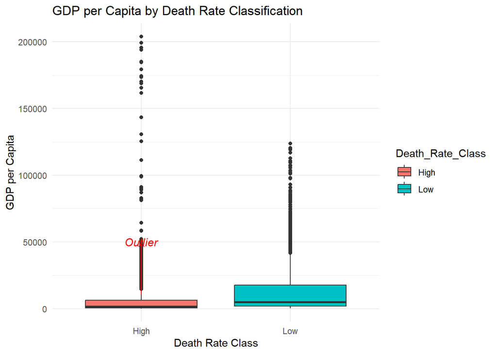

```r
#Boxplot for GDP

ggplot(merged_data3,aes(x=Death_Rate_Class,y=GDP_per_capita,fill=Death_Rate_Class))+
  geom_boxplot()+
  labs(title= "GDP per Capita by Death Rate Classification", x = "Death Rate Class", y = "GDP per Capita") +
  theme_minimal()+
  annotate("text", x = 1, y = 50000, label = "Outlier", color = "red", size = 4, fontface = "italic") +
  annotate("segment", x = 1, xend = 1, y = 10000, yend = 50000, color = "red", arrow = arrow(length = unit(0.2, "cm")))
```

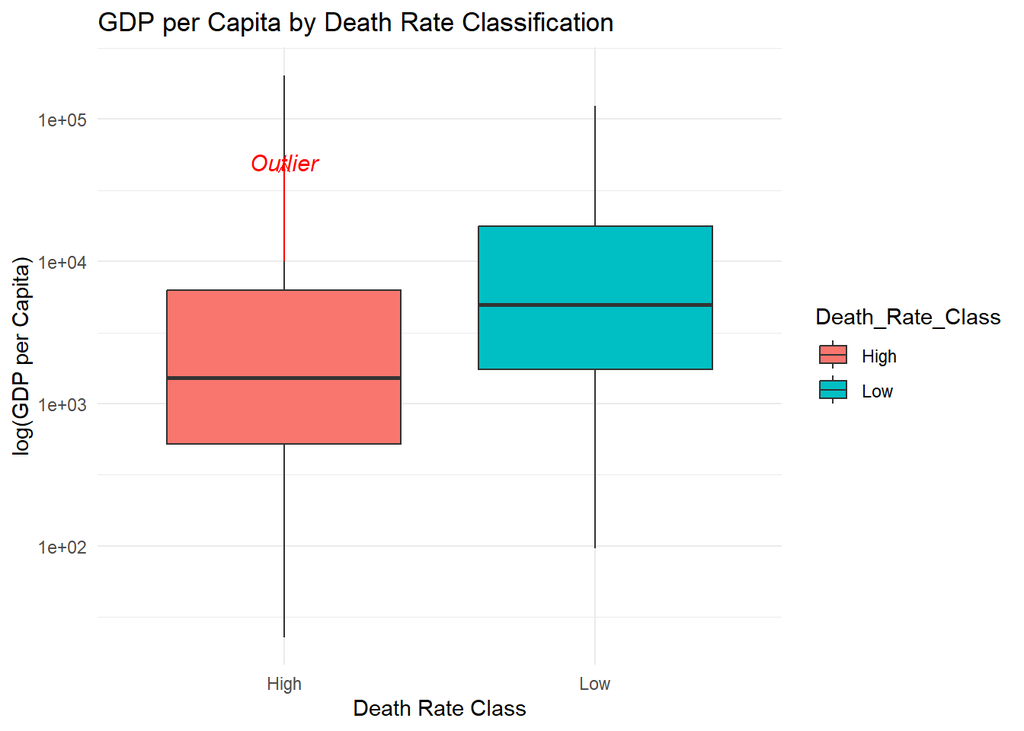

```r
#transformed
ggplot(merged_data3,aes(x=Death_Rate_Class,y=GDP_per_capita,fill=Death_Rate_Class))+
  geom_boxplot()+
  scale_y_log10() +
  labs(title= "GDP per Capita by Death Rate Classification", x = "Death Rate Class", y = "log(GDP per Capita)") +
  theme_minimal()+
  annotate("text", x = 1, y = 50000, label = "Outlier", color = "red", size = 4, fontface = "italic") +
  annotate("segment", x = 1, xend = 1, y = 10000, yend = 50000, color = "red", arrow = arrow(length = unit(0.2, "cm")))
```

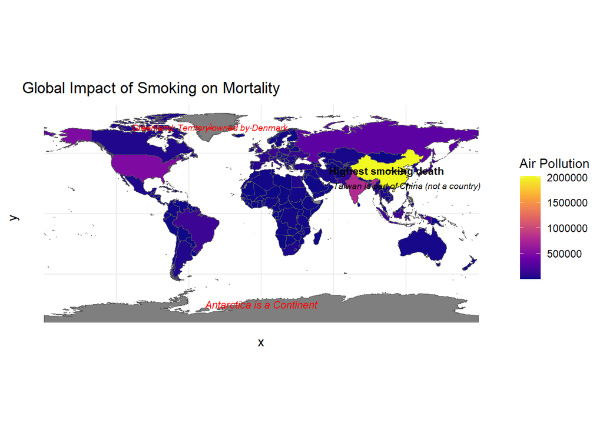

```r
# Map Viz-Load world map data
world <- ne_countries(scale = "medium", returnclass = "sf")

# Rename "United States" to "United States of America" in your dataset
merged_data_US <- merged_data3 %>%
  mutate(Country = ifelse(Country == "United States", "United States of America", Country),
         Country = ifelse(Country == "South Sudan", "S. Sudan", Country),
         Country = ifelse(Country == "Central African Republic", "Central African Rep.", Country),
         Country = ifelse(Country == "Eswatini", "eSwatini", Country),
         Country = ifelse(Country == "Micronesia (country)", "Micronesia", Country),
         Country = ifelse(Country == "East Timor", "Timor-Leste", Country),
         Country = ifelse(Country == "Dominican Republic", "Dominican Rep.", Country),
         Country = ifelse(Country == "Democratic Republic of Congo", "Dem. Rep. Congo", Country),
         Country = ifelse(Country == "Cape Verde", "Cabo Verde", Country),
         Country = ifelse(Country == "Antigua and Barbuda", "Antigua and Barb.", Country),
         Country = ifelse(Country == "Bosnia and Herzegovina", "Bosnia and Herz.", Country),
         Country = ifelse(Country == "Cote d'Ivoire", "Côte d'Ivoire", Country),
         Country = ifelse(Country == "Equatorial Guinea", "Eq. Guinea", Country),
         Country = ifelse(Country == "Marshall Islands", "Marshall Is.", Country),
         Country = ifelse(Country == "Northern Mariana Islands", "N. Mariana Is.", Country),
         Country = ifelse(Country == "Saint Kitts and Nevis", "St. Kitts and Nevis", Country),
         Country = ifelse(Country == "Saint Vincent and the Grenadines", "St. Vin. and Gren.", Country),
         Country = ifelse(Country == "Sao Tome and Principe", "São Tomé and Principe", Country),
         Country = ifelse(Country == "Solomon Islands", "Solomon Is.", Country))

# Prepare the dataset for merging
map_data <- merged_data_US %>%
  dplyr::select(Country, Smoking) %>%
  group_by(Country) %>%
  summarise(Air.pollution = mean(Smoking, na.rm = TRUE))

# Merge the map data with your dataset
world_data <- left_join(world, map_data, by = c("name" = "Country"))

# Plot the map with Outdoor air pollution
ggplot(data = world_data) +
  geom_sf(aes(fill = Air.pollution)) +
  scale_fill_viridis_c(option = "C", na.value = "grey50") +
  labs(title = "Global Impact of Smoking on Mortality ", fill = "Air Pollution") +
  theme_minimal()+
  annotate("text", x = 104.1954, y = 35.8617, label = "Highest smoking death", color = "black", size = 3, fontface = "bold") +
  annotate("segment", x = 104.1954, xend = 120, y = 35.8617, yend = 35, color = "black", arrow = arrow(length = unit(0.2, "cm"))) +

 annotate("text", x = 120.9605, y = 23.6978, label = "Taiwan is part of China (not a country)", color = "black", size = 2.5, fontface = "italic") +
  annotate("segment", x = 120.9605, xend = 120, y = 23.6978, yend = 25, color = "black", arrow = arrow(length = unit(0.2, "cm"))) +
  annotate("text", x = -42.6043, y = 71.7069, label = "Greenland: Territory owned by Denmark", color = "red", size = 2.5, fontface = "italic") +
  annotate("segment", x = -42.6043, xend = -40, y = 71.7069, yend = 70, color = "red", arrow = arrow(length = unit(0.2, "cm"))) +
  annotate("text", x = 0, y = -75, label = "Antarctica is a Continent", color = "red", size = 3, fontface = "italic")
```

```r
  annotate("text", x = 0, y = -75, label = "Antarctica is a Continent", color = "red", size = 4, fontface = "italic")
```

```
## mapping: x = ~x, y = ~y
## geom_text: na.rm = FALSE
## stat_identity: na.rm = FALSE
## position_identity
```

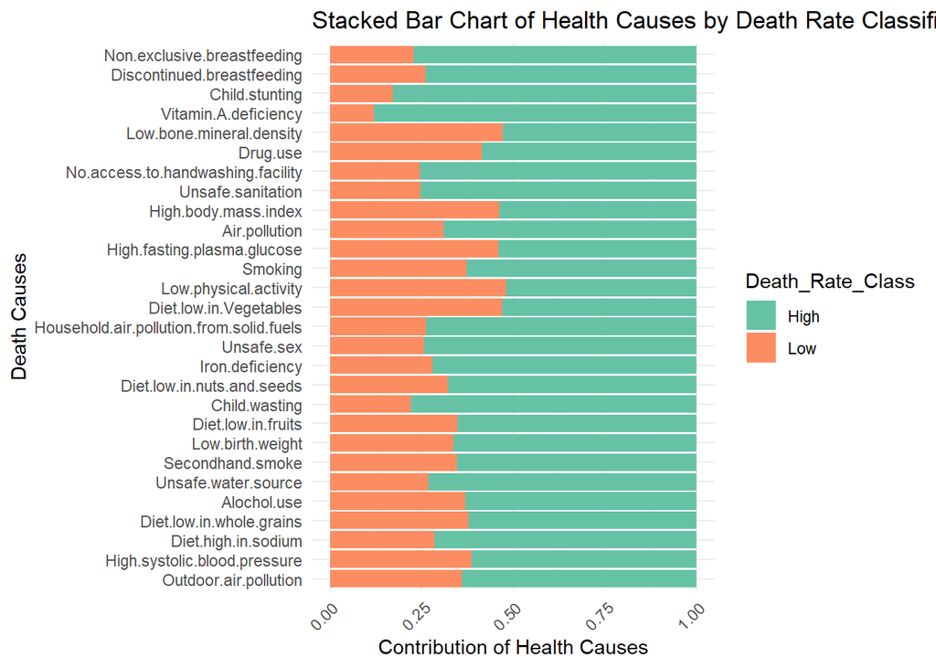

```r
# Assuming multiple death causes like Air Pollution, Blood Pressure, and Sodium Intake
death_causes <- merged_data3[, c("Outdoor.air.pollution", "High.systolic.blood.pressure", "Diet.high.in.sodium",
                                 "Diet.low.in.whole.grains","Alochol.use","Unsafe.water.source","Secondhand.smoke",
                               "Low.birth.weight","Diet.low.in.fruits","Child.wasting","Diet.low.in.nuts.and.seeds","Iron.deficiency",
                               "Unsafe.sex","Household.air.pollution.from.solid.fuels","Diet.low.in.Vegetables","Low.physical.activity",
                               "Smoking", "High.fasting.plasma.glucose","Air.pollution","High.body.mass.index","Unsafe.sanitation",
                               "No.access.to.handwashing.facility","Drug.use" ,"Low.bone.mineral.density","Vitamin.A.deficiency",
                               "Child.stunting","Discontinued.breastfeeding","Non.exclusive.breastfeeding","Death_Rate_Class")]

# Melt data for ggplot
death_causes_melted <- melt(death_causes, id.vars = "Death_Rate_Class",
                            variable.name = "Death_Cause", value.name = "Value")

# Stacked bar chart with Death Cause on the x-axis and Death Rate Classification stacked
ggplot(death_causes_melted, aes(x = Death_Cause, y = Value, fill = Death_Rate_Class)) +
  geom_bar(stat = "identity", position = "fill") +
  labs(title = "Stacked Bar Chart of Health Causes by Death Rate Classification",
       x = "Death Causes", y = "Contribution of Health Causes") +
  theme_minimal() +
  coord_flip()+
  scale_fill_brewer(palette = "Set2") +
  theme(axis.text.x = element_text(angle = 45, hjust = 1))
```

2.The histograms of population shows the distribution of countries by population, the first diagram show there’s a right skewness and also indicating that the data is not properly distributed since the numbers of population may rage over a million and needs to to be transformed to see the precise distribution.

After the transformation(log-transformed). Most countries fall within a specific population range (around 10 million). This helps to show the skewness in population distribution, with fewer countries having very high populations.

After the transformation.Countries with lower death rates tend to have higher GDP per capita, which suggests that wealthier countries may have better healthcare and lower death rates. There’s an outlier identified in the high death rate group.

4.The world map shows the death counts by smoking accross countries.To do so, we import the rnaturalearth which include sf that holds and facilitates interaction with natural earth map data(Rnaturalearth Package - RDocumentation, n.d.).The map reveals significant smokers in certain countries, particularly in densely populated regions such as China which had most of the deaths by smoking. This can be a useful visualization for correlating smoking with other health outcomes .

# Classification

## Decision Tree

```r
#FORMULA

#performance measures
performanceMeasures <- function(ytrue, ypred, model.name = "model") {
  cmat <- table(actual = ytrue, predicted = ypred )#confmatrix
  accuracy <- sum(diag(cmat)) / sum(cmat)#accuracy
  precision <- cmat[2, 2] / sum(cmat[, 2])#precision
  recall <- cmat[2, 2] / sum(cmat[2, ]) #recall
  f1 <- 2 * precision * recall / (precision + recall) # F1 Score
  # Return the results in a data frame
  data.frame(model = model.name, precision = precision, recall = recall, f1 = f1, accuracy = accuracy)
}
```

This is a function to measure the performance of each classifier that is used during the project which contains accuracy,precision,recall and f1.The number they provide can also gives us information whether our model is overfitting or not.

```r
#Decision Tree
library(caret)
```

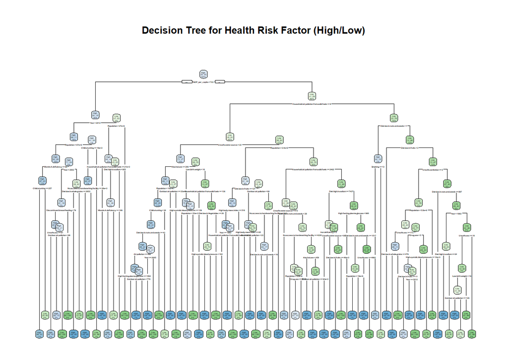

```r
library(rpart)
library(rpart.plot)
library(ROCit)
#Split test and training data and deploy Decision Tree
set.seed(123)

# Split data into training and test sets
split_index <- createDataPartition(merged_data3$Death_Rate_Class, p = 0.8, list = FALSE)
train_data <- merged_data3[split_index, ]
test_data <- merged_data3[-split_index, ]

# Further split the test set to create a calibration set (50% of test data)
cal_index <- createDataPartition(test_data$Death_Rate_Class, p = 0.8, list = FALSE)
dCal <- test_data[cal_index, ]
test_data2 <- test_data[-cal_index, ]

# Train Decision Tree model
tree_model <- rpart(Death_Rate_Class ~ .-`Country Code`- Country - Death_Rate_Proxy - Death_Proxy_Proportion,
                    data = train_data, method = "class",
                    control = rpart.control(cp = 0.001, minsplit = 10, maxdepth = 10))

# Visualize the Decision Tree
rpart.plot(tree_model, extra = 104, fallen.leaves = TRUE, main = "Decision Tree for Health Risk Factor (High/Low)")
```

```r
# Predictions for Test Data
predictions_tree_test <- predict(tree_model, newdata = test_data2, type = "class")

# Confusion Matrix for Test Data
cmat2 <- table(actual = test_data2$Death_Rate_Class, predicted = predictions_tree_test)
print(cmat2)
```

```
##       predicted
## actual High Low
##   High  107   8
##   Low     6 109
```

```r
# Performance Measures for Test Data
performance_tree <- performanceMeasures(test_data2$Death_Rate_Class, predictions_tree_test, model.name = "Decision Tree")
print(performance_tree)
```

```
##           model precision    recall        f1  accuracy
## 1 Decision Tree 0.9316239 0.9478261 0.9396552 0.9391304
```

```r
# ROC and AUC for Training, Test, and Calibration Data
predictions_prob_train <- predict(tree_model, newdata = train_data, type = "prob")[, 2]  # Probability for "High" class
predictions_prob_test <- predict(tree_model, newdata = test_data2, type = "prob")[, 2]   # Probability for "High" class
predictions_prob_cal <- predict(tree_model, newdata = dCal, type = "prob")[, 2]         # Probability for "High" class

# ROC Curves
rocit_train <- rocit(score = predictions_prob_train, class = train_data$Death_Rate_Class)
rocit_test <- rocit(score = predictions_prob_test, class = test_data2$Death_Rate_Class)
rocit_cal <- rocit(score = predictions_prob_cal, class = dCal$Death_Rate_Class)

# Print AUC for all datasets
rocit_train$AUC
```

```
## [1] 0.9841651
```

```r
rocit_test$AUC
```

```
## [1] 0.9701701
```

```r
rocit_cal$AUC
```

```
## [1] 0.9484945
```

For the Decision Tree, the model started with the whole features except Country Code, Country, Death_Rate_Proxy, Death_Proxy_Proportion.The reason for Country Code and Country since they have extremely high importance compared to the others as well as the decision tree might be relying on geographical identifiers such as country. For Death_Rate_Proxy and Death_Proxy_Proportion is just for feature engineering and the existence of the variable is for determining the target variable which is Death_Rate_Class.

## Feature Selection: Feature Importance

```r
# Get feature importance
importance <- varImp(tree_model)
print(importance)
```

```
##                                            Overall
## Air.pollution                            250.60414
## Alochol.use                              399.50063
## Child.stunting                            72.29858
## Child.wasting                             83.99307
## Diet.high.in.sodium                      281.86532
## Diet.low.in.fruits                       353.76441
## Diet.low.in.nuts.and.seeds               452.36207
## Diet.low.in.Vegetables                   105.91589
## Diet.low.in.whole.grains                 252.65177
## Discontinued.breastfeeding                75.79061
## Drug.use                                 105.48051
## GDP_per_capita                           323.04571
## High.body.mass.index                     124.72041
## High.fasting.plasma.glucose              102.80406
## High.systolic.blood.pressure             205.80731
## Household.air.pollution.from.solid.fuels 513.14906
## Iron.deficiency                          177.71057
## Low.birth.weight                         228.64266
## Low.bone.mineral.density                 213.86695
## Low.physical.activity                     85.28437
## No.access.to.handwashing.facility        541.39279
## Non.exclusive.breastfeeding               66.31923
## Outdoor.air.pollution                    310.34370
## Population                               454.83696
## Secondhand.smoke                         167.93664
## Smoking                                   50.63529
## Unsafe.sanitation                        550.72525
## Unsafe.sex                               255.60139
## Unsafe.water.source                      382.88979
## Vitamin.A.deficiency                     372.10140
## Year                                      83.15983
```

One of the Feature selection used for Decision Tree is Feature Importance and using varImp() to generate the importance score based on the first model(varImp Function - RDocumentation, n.d.). From here we can determine the threshold on the basis of the overall score from each variable.

Given from the result most of the variables has the overall score greater than 100. Which means there are a lot of variables that can be used in the second model.

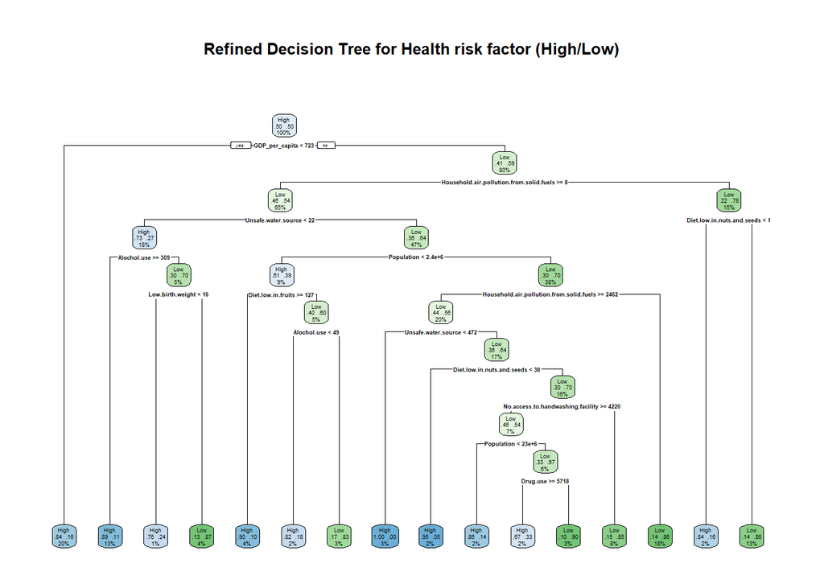

```r
#Second DT Model
# Selected important features (you should define 'selected_features' based on importance scores)
selected_features <- rownames(importance)[importance$Overall > 100]  # Example threshold
dCal_selected <- dCal[, c(selected_features, "Death_Rate_Class")] # calibration
train_data_selected<-train_data[, c(selected_features, "Death_Rate_Class")]

# Retrain the model with the selected features
tree_model_threshold <- rpart(Death_Rate_Class ~ ., data = train_data_selected, method = "class")
# Visualize the refined tree
rpart.plot(tree_model_threshold, extra = 104, fallen.leaves = TRUE, main = "Refined Decision Tree for Health risk factor (High/Low)")
```

```r
test_data_selected <- test_data2[, c(selected_features, "Death_Rate_Class")]

# Predict on the test data using the refined model
predictions_tree_refined <- predict(tree_model_threshold, newdata = test_data_selected, type = "class")

# Confusion matrix for refined model
cmat_refined <- table(actual = test_data_selected$Death_Rate_Class, predicted = predictions_tree_refined)
print(cmat_refined)
```

```
##       predicted
## actual High Low
##   High   96  19
##   Low    16  99
```

```r
# Performance measures for the refined model
performance_tree_refined <- performanceMeasures(test_data_selected$Death_Rate_Class, predictions_tree_refined, model.name = "Refined Decision Tree")
print(performance_tree_refined)
```

```
##                   model precision    recall        f1  accuracy
## 1 Refined Decision Tree 0.8389831 0.8608696 0.8497854 0.8478261
```

```r
### Predictions for the data
predictions_tree_train_prob <- predict(tree_model_threshold, newdata = train_data_selected, type = "prob")[,2]
predictions_tree_test_prob <- predict(tree_model_threshold, newdata = test_data_selected, type = "prob")[,2]
predictions_tree_cal_prob <- predict(tree_model_threshold, newdata = dCal_selected, type = "prob")[,2]

# ROC curve for the training data
rocit_train <- rocit(score = predictions_tree_train_prob, class = train_data_selected$Death_Rate_Class)
rocit_test <- rocit(score = predictions_tree_test_prob, class = test_data_selected$Death_Rate_Class)
rocit_cal <- rocit(score = predictions_tree_cal_prob, class = dCal_selected$Death_Rate_Class)

# AUC values using ROCit
rocit_train$AUC
```

```
## [1] 0.8775678
```

```r
rocit_test$AUC
```

```
## [1] 0.8615879
```

```r
rocit_cal$AUC
```

```
## [1] 0.8295815
```

Then, we select the feature on the basis of threshold which is greater than 100. So feature that has a score below 100 will not be selected for the second model and then repeat the process as the first model

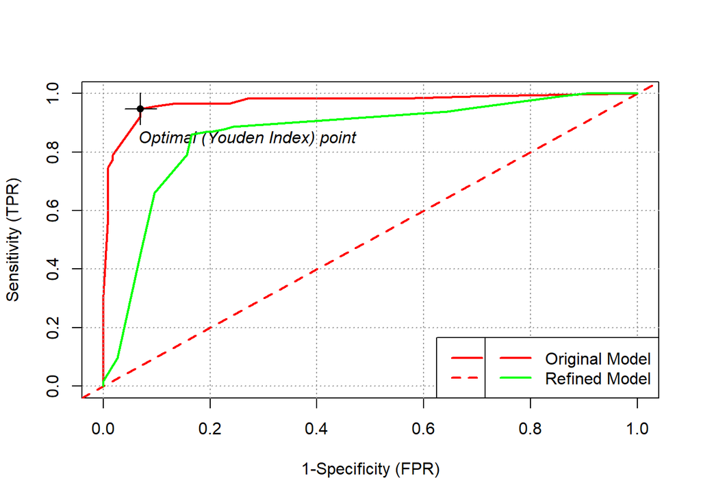

```r
# ROC and AUC for the test data from both original and refined models

# Predictions probabilities for the test data from the original and refined models
predictions_prob_test_original <- predict(tree_model, newdata = test_data2, type = "prob")[, 2]   # Original model
predictions_prob_test_refined <- predict(tree_model_threshold, newdata = test_data_selected, type = "prob")[, 2]  # Refined model

# ROC Curves using ROCit for test data
rocit_test_original <- rocit(score = predictions_prob_test_original, class = test_data2$Death_Rate_Class)
rocit_test_refined <- rocit(score = predictions_prob_test_refined, class = test_data_selected$Death_Rate_Class)

# Plot ROC curves for the test data from both models
plot(rocit_test_original, col = "red", main = "ROC Curves for Test Data (Original vs Refined Model)", lwd = 2)
lines(rocit_test_refined$TPR ~ rocit_test_refined$FPR, col = "green", lwd = 2)

# Add legend to distinguish between models
legend("bottomright", legend = c("Original Model", "Refined Model"), col = c("red", "green"), lwd = 2)
```

```r
# AUC values for both models
cat("AUC for Original Model:", rocit_test_original$AUC, "\n")
```

```
## AUC for Original Model: 0.9701701
```

```r
cat("AUC for Refined Model:", rocit_test_refined$AUC, "\n")
```

```
## AUC for Refined Model: 0.8615879
```

## Logistic Regression

```r
log_data <- merged_data3
# Convert 'Death_Rate_Class' into binary (1 for High, 0 for Low)
log_data$Death_Rate_Class <- ifelse(log_data$Death_Rate_Class == "High", 1, 0)
log_data$Death_Rate_Class<- as.factor(log_data$Death_Rate_Class)
# Step 1: Create a copy of the dataset and scale the numerical variables
numeric_cols <- sapply(log_data, is.numeric)  # Select only numeric columns
columns_to_remove <- c("Country", "Country Code", "Death_Proxy_Proportion", "Death_Rate_Proxy", "Death_Rate_Class")  # Columns to exclude along with target variable
log_data_numeric <- log_data[, numeric_cols]
log_data_numeric <- log_data_numeric[, !(names(log_data_numeric) %in% columns_to_remove)]  # Remove unwanted columns

# Step 2: Scale the remaining numerical data (excluding the target variable)
log_data_scaled <- scale(log_data_numeric)

log_data_scaled_df <- as.data.frame(log_data_scaled)

# Step 4: Add back the target variable (Death_Rate_Class) to the scaled dataset
log_data_final <- cbind(log_data_scaled_df, Death_Rate_Class = log_data$Death_Rate_Class)

# Step 4: Split the dataset into train and test sets (80/20 split)
set.seed(123)  # Set seed for reproducibility
split_index <- createDataPartition(log_data_final$Death_Rate_Class, p = 0.8, list = FALSE)
train_data_log <- log_data_final[split_index, ]
test_data_log <- log_data_final[-split_index, ]

# Further split the test set to create a calibration set (80% of test data)
cal_index <- createDataPartition(test_data_log$Death_Rate_Class, p = 0.8, list = FALSE)
dCal <- test_data_log[cal_index, ]
test_data_log2 <- test_data_log[-cal_index, ]

# Step 5: Fit the logistic regression model (exclude country and proxy variables)
logistic_model <- glm(Death_Rate_Class ~ .,
                      data = train_data_log, family = binomial(link = "logit"))
# Step 6: Model summary
summary(logistic_model)
```

```
##
## Call:
## glm(formula = Death_Rate_Class ~ ., family = binomial(link = "logit"),
##     data = train_data_log)
##
## Coefficients:
##                                            Estimate Std. Error    z value
## (Intercept)                               7.142e+14  9.893e+05  7.219e+08
## Year                                     -3.551e+14  1.107e+06 -3.207e+08
## Outdoor.air.pollution                     1.243e+16  2.163e+08  5.747e+07
## High.systolic.blood.pressure              2.139e+15  2.774e+07  7.711e+07
## Diet.high.in.sodium                       4.026e+15  1.665e+07  2.418e+08
## Diet.low.in.whole.grains                 -5.537e+14  1.562e+07 -3.544e+07
## Alochol.use                              -2.333e+15  6.224e+06 -3.749e+08
## Diet.low.in.fruits                        2.011e+14  1.974e+07  1.019e+07
## Unsafe.water.source                       9.588e+15  4.973e+07  1.928e+08
## Secondhand.smoke                         -1.491e+15  2.624e+07 -5.682e+07
## Low.birth.weight                          1.300e+15  1.286e+07  1.011e+08
## Child.wasting                             2.314e+15  1.235e+07  1.874e+08
## Unsafe.sex                                8.080e+14  1.455e+06  5.554e+08
## Diet.low.in.nuts.and.seeds                7.454e+14  8.805e+06  8.466e+07
## Household.air.pollution.from.solid.fuels  1.815e+16  2.073e+08  8.755e+07
## Diet.low.in.Vegetables                   -7.388e+13  8.000e+06 -9.236e+06
## Low.physical.activity                     2.176e+15  8.774e+06  2.480e+08
## Smoking                                   5.354e+15  1.876e+07  2.854e+08
## High.fasting.plasma.glucose               5.152e+15  1.454e+07  3.543e+08
## Air.pollution                            -2.061e+16  4.070e+08 -5.064e+07
## High.body.mass.index                      2.140e+14  1.173e+07  1.823e+07
## Unsafe.sanitation                        -6.725e+15  4.026e+07 -1.671e+08
## No.access.to.handwashing.facility         2.237e+15  1.962e+07  1.140e+08
## Drug.use                                  8.280e+14  5.005e+06  1.654e+08
## Low.bone.mineral.density                  7.570e+14  1.137e+07  6.655e+07
## Vitamin.A.deficiency                     -3.080e+14  4.981e+06 -6.184e+07
## Child.stunting                           -4.158e+15  1.217e+07 -3.417e+08
## Discontinued.breastfeeding               -2.210e+14  4.402e+06 -5.020e+07
## Non.exclusive.breastfeeding               1.008e+15  8.626e+06  1.168e+08
## Iron.deficiency                          -8.952e+14  9.939e+06 -9.007e+07
## GDP_per_capita                           -1.489e+14  1.113e+06 -1.338e+08
## Population                               -2.659e+16  1.627e+07 -1.635e+09
##                                          Pr(>|z|)
```

[output cut: 27 more lines]

```
## Discontinued.breastfeeding                 <2e-16 ***
## Non.exclusive.breastfeeding                <2e-16 ***
## Iron.deficiency                            <2e-16 ***
## GDP_per_capita                             <2e-16 ***
## Population                                 <2e-16 ***
## ---
## Signif. codes:  0 '***' 0.001 '**' 0.01 '*' 0.05 '.' 0.1 ' ' 1
##
## (Dispersion parameter for binomial family taken to be 1)
##
##     Null deviance:  6388  on 4607  degrees of freedom
## Residual deviance: 99553  on 4576  degrees of freedom
## AIC: 99617
##
## Number of Fisher Scoring iterations: 25
```

```r
# Step 7: Predict on the train, test, and calibration data
predictions_Log_train <- predict(logistic_model, newdata = train_data_log, type = "response")
predictions_Log <- predict(logistic_model, newdata = test_data_log2, type = "response")
predictions_Log_Cal <- predict(logistic_model, newdata = dCal, type = "response")

# Convert probabilities to binary classes (0 or 1)
predicted_classes_Log <- ifelse(predictions_Log > 0.5, 1, 0)

# Step 8: Confusion matrix: Compare actual test classes with predicted binary classes
cmat <- table(actual = test_data_log2$Death_Rate_Class, predicted = predicted_classes_Log)
print(cmat)
```

```
##       predicted
## actual   0   1
##      0  58  57
##      1   2 113
```

```r
performance_Log <- performanceMeasures(test_data_log2$Death_Rate_Class, predictions_Log, model.name = "Logistic Regression")
performance_Log
```

```
##                 model precision    recall        f1  accuracy
## 1 Logistic Regression 0.6647059 0.9826087 0.7929825 0.7434783
```

```r
# Step 9: ROC and AUC for training, test, and calibration data
rocit_log_train <- rocit(score = predictions_Log_train, class = train_data_log$Death_Rate_Class)
rocit_log_test <- rocit(score = predictions_Log, class = test_data_log2$Death_Rate_Class)
rocit_log_cal <- rocit(score = predictions_Log_Cal, class = dCal$Death_Rate_Class)

# Step 11: Print AUC values for training, test, and calibration sets
print(paste("AUC (Training):", rocit_log_train$AUC))
```

```
## [1] "AUC (Training): 0.700303819444444"
```

```r
print(paste("AUC (Testing):", rocit_log_test$AUC))
```

```
## [1] "AUC (Testing): 0.743478260869565"
```

```r
print(paste("AUC (Calibration):", rocit_log_cal$AUC))
```

```
## [1] "AUC (Calibration): 0.719088937093276"
```

For Logistic Regression, the model also started with the whole features except for Country Code,Country,Death_Rate_Proxy and Death_Proxy_Proportion. The reason for Country Code and Country since they have extremely high importance compared to the others. For Death_Rate_Proxy and Death_Proxy_Proportion is just for feature engineering and the existence of the variable is for determining the target variable which is Death_Rate_Class.

However, the data needs to be scaled first for logistic model and decided to duplicate the data to separate the normal data and the scaled one. Before scaling the data, the non numeric data type needs to be removed first since scaling can be done with numerical only and then adding back the target variable.

## Feature Selection: Forward Selection

```r
# Fit an initial null model with no predictors
null_model <- glm(Death_Rate_Class ~ 1, data = log_data_final, family = binomial(link = "logit"))

# Fit a full model with all predictors
full_model <- glm(Death_Rate_Class ~ ., data = log_data_final, family = binomial(link = "logit"))
# Perform forward selection
forward_model <- step(null_model,
                      scope = list(lower = null_model, upper = full_model),
                      direction = "forward",
                      trace = 0)
```

[output not shown]

[output cut: 238 more lines]

[output not shown]

[output not shown]

[output not shown]

[output cut: 30 more lines]

[output not shown]

```r
forward_model
```

```
##
## Call:  glm(formula = Death_Rate_Class ~ Vitamin.A.deficiency + Unsafe.water.source +
##     Diet.low.in.nuts.and.seeds + Population + Smoking + Child.wasting +
##     Unsafe.sex + Outdoor.air.pollution + High.fasting.plasma.glucose +
##     Diet.high.in.sodium + Low.birth.weight + High.systolic.blood.pressure +
##     No.access.to.handwashing.facility + Child.stunting + Iron.deficiency +
##     Air.pollution + Drug.use + Alochol.use + Year + High.body.mass.index +
##     Diet.low.in.whole.grains, family = binomial(link = "logit"),
##     data = log_data_final)
##
## Coefficients:
##                       (Intercept)               Vitamin.A.deficiency
##                         2.911e+02                          1.086e+02
##               Unsafe.water.source         Diet.low.in.nuts.and.seeds
##                         2.037e+03                          2.817e+02
##                        Population                            Smoking
##                        -1.897e+04                          3.020e+03
##                     Child.wasting                         Unsafe.sex
##                         8.285e+02                          3.367e+02
##             Outdoor.air.pollution        High.fasting.plasma.glucose
##                         2.716e+02                          1.581e+03
##               Diet.high.in.sodium                   Low.birth.weight
##                         1.095e+03                          9.793e+02
##      High.systolic.blood.pressure  No.access.to.handwashing.facility
##                         3.260e+03                          2.070e+02
##                    Child.stunting                    Iron.deficiency
##                         3.772e+02                          4.687e+01
##                     Air.pollution                           Drug.use
##                         6.243e+03                          3.394e+02
##                       Alochol.use                               Year
##                         6.341e+02                         -1.759e-02
##              High.body.mass.index           Diet.low.in.whole.grains
##                         9.421e+02                          6.713e+02
##
## Degrees of Freedom: 5759 Total (i.e. Null);  5738 Residual
## Null Deviance:       7985
## Residual Deviance: 536.2     AIC: 580.2
```

```r
# Second Logistic Model
# Create the formula dynamically from the selected variables

logistic_model_selected <-  glm(formula = Death_Rate_Class ~ Vitamin.A.deficiency + Unsafe.water.source +
    Diet.low.in.nuts.and.seeds + Population + Smoking + Child.wasting +
    Unsafe.sex + Outdoor.air.pollution + High.fasting.plasma.glucose +
    Diet.high.in.sodium + Low.birth.weight + High.systolic.blood.pressure +
    No.access.to.handwashing.facility + Child.stunting + Iron.deficiency +
    Air.pollution + Drug.use + Alochol.use + Year + High.body.mass.index +
    Diet.low.in.whole.grains, family = binomial(link = "logit"),
    data = log_data_final)
# Model summary
summary(logistic_model_selected)
```

```
##
## Call:
## glm(formula = Death_Rate_Class ~ Vitamin.A.deficiency + Unsafe.water.source +
##     Diet.low.in.nuts.and.seeds + Population + Smoking + Child.wasting +
##     Unsafe.sex + Outdoor.air.pollution + High.fasting.plasma.glucose +
##     Diet.high.in.sodium + Low.birth.weight + High.systolic.blood.pressure +
##     No.access.to.handwashing.facility + Child.stunting + Iron.deficiency +
##     Air.pollution + Drug.use + Alochol.use + Year + High.body.mass.index +
##     Diet.low.in.whole.grains, family = binomial(link = "logit"),
##     data = log_data_final)
##
## Coefficients:
##                                     Estimate Std. Error z value Pr(>|z|)
## (Intercept)                        2.911e+02  2.208e+01  13.184  < 2e-16 ***
## Vitamin.A.deficiency               1.086e+02  4.851e+01   2.238  0.02519 *
## Unsafe.water.source                2.037e+03  2.198e+02   9.268  < 2e-16 ***
## Diet.low.in.nuts.and.seeds         2.817e+02  2.334e+01  12.069  < 2e-16 ***
## Population                        -1.897e+04  1.401e+03 -13.541  < 2e-16 ***
## Smoking                            3.020e+03  2.240e+02  13.483  < 2e-16 ***
## Child.wasting                      8.285e+02  1.266e+02   6.544    6e-11 ***
## Unsafe.sex                         3.367e+02  2.712e+01  12.416  < 2e-16 ***
## Outdoor.air.pollution              2.716e+02  8.737e+01   3.109  0.00188 **
## High.fasting.plasma.glucose        1.581e+03  1.191e+02  13.277  < 2e-16 ***
## Diet.high.in.sodium                1.095e+03  1.233e+02   8.884  < 2e-16 ***
## Low.birth.weight                   9.793e+02  8.276e+01  11.833  < 2e-16 ***
## High.systolic.blood.pressure       3.260e+03  2.600e+02  12.539  < 2e-16 ***
## No.access.to.handwashing.facility  2.070e+02  1.869e+02   1.108  0.26782
## Child.stunting                     3.772e+02  1.687e+02   2.236  0.02533 *
## Iron.deficiency                    4.687e+01  3.334e+01   1.406  0.15980
## Air.pollution                      6.243e+03  4.800e+02  13.005  < 2e-16 ***
## Drug.use                           3.394e+02  3.205e+01  10.591  < 2e-16 ***
## Alochol.use                        6.341e+02  5.087e+01  12.466  < 2e-16 ***
## Year                              -1.759e-02  1.143e-01  -0.154  0.87766
## High.body.mass.index               9.421e+02  7.556e+01  12.469  < 2e-16 ***
## Diet.low.in.whole.grains           6.713e+02  6.113e+01  10.982  < 2e-16 ***
## ---
## Signif. codes:  0 '***' 0.001 '**' 0.01 '*' 0.05 '.' 0.1 ' ' 1
##
## (Dispersion parameter for binomial family taken to be 1)
##
##     Null deviance: 7985.06  on 5759  degrees of freedom
## Residual deviance:  536.23  on 5738  degrees of freedom
## AIC: 580.23
##
## Number of Fisher Scoring iterations: 21
```

```r
selected_features <- c("Vitamin.A.deficiency", "Unsafe.water.source",
                       "Diet.low.in.nuts.and.seeds", "Population", "Smoking",
                       "Child.wasting", "Unsafe.sex", "Outdoor.air.pollution",
                       "High.fasting.plasma.glucose", "Diet.high.in.sodium",
                       "Low.birth.weight", "High.systolic.blood.pressure",
                       "No.access.to.handwashing.facility", "Child.stunting",
                       "Iron.deficiency", "Air.pollution", "Drug.use", "Alochol.use",
                       "Year", "High.body.mass.index", "Diet.low.in.whole.grains")

# Subset train, test, and calibration data to only include selected features
train_data_log_s <- train_data_log[, c(selected_features, "Death_Rate_Class")]
test_data_log2_s <- test_data_log2[, c(selected_features, "Death_Rate_Class")]
dCal_s <- dCal[, c(selected_features, "Death_Rate_Class")]


# Step 2: Predict on the test data using the selected model
# Predict probabilities on the test data
predictions_Log_train_selected <- predict(logistic_model_selected, newdata = train_data_log_s, type = "response")
predictions_Log_selected <- predict(logistic_model_selected, newdata = test_data_log2_s, type = "response")
predictions_Log_Cal_selected <- predict(logistic_model_selected, newdata = dCal_s, type = "response")

# Convert probabilities to binary classes (0 or 1)
predicted_classes_Log_selected <- ifelse(predictions_Log_selected > 0.5, 1, 0)

# Confusion matrix: Compare actual test classes with predicted binary classes
cmat_selected <- table(actual = test_data_log2_s$Death_Rate_Class, predicted = predicted_classes_Log_selected)
print("Confusion Matrix:")
```

```
## [1] "Confusion Matrix:"
```

```r
print(cmat_selected)
```

```
##       predicted
## actual   0   1
##      0 115   0
##      1   2 113
```

```r
# Performance Measures (assuming you have a custom function for this)
performance_Log <- performanceMeasures(test_data_log2_s$Death_Rate_Class, predicted_classes_Log_selected, model.name = "Logistic Regression")
performance_Log
```

```
##                 model precision    recall        f1  accuracy
## 1 Logistic Regression         1 0.9826087 0.9912281 0.9913043
```

```r
# ROC and AUC for training and test data
rocit_log_train <- rocit(score = predictions_Log_train_selected, class = train_data_log_s$Death_Rate_Class)
rocit_log_test <- rocit(score = predictions_Log_selected, class = test_data_log2_s$Death_Rate_Class)
rocit_log_cal <- rocit(score = predictions_Log_Cal_selected, class = dCal_s$Death_Rate_Class)

# Step 5: Print AUC values for training, test, and calibration sets using ROCit
print(paste("AUC (Training):", rocit_log_train$AUC))
```

```
## [1] "AUC (Training): 0.999185821156443"
```

```r
print(paste("AUC (Testing):", rocit_log_test$AUC))
```

```
## [1] "AUC (Testing): 0.99992438563327"
```

```r
print(paste("AUC (Calibration):", rocit_log_cal$AUC))
```

```
## [1] "AUC (Calibration): 0.999322419902033"
```

There are several way to minimize the potential of overfitting. a feature selection is one which has been done above for the second model however the result is yet to be convincing. there is also called regularization which will be done in the next step.

## Regularization (Lasso)

```r
library(glmnet)
# Step 1: Prepare the data for glmnet
# Convert data into matrix format for glmnet
X_train <- as.matrix(train_data_log[ , !(names(train_data_log) %in% c("Death_Rate_Class"))])  # Exclude target
y_train <- as.numeric(as.character(train_data_log$Death_Rate_Class))  # Convert factor to numeric

X_test <- as.matrix(test_data_log2[ , !(names(test_data_log2) %in% c("Death_Rate_Class"))])  # Test data
y_test <- as.numeric(as.character(test_data_log2$Death_Rate_Class))  # Test labels

# Calibration data
X_cal <- as.matrix(dCal[ , !(names(dCal) %in% c("Death_Rate_Class"))])  # Calibration data
y_cal <- as.numeric(as.character(dCal$Death_Rate_Class))  # Calibration labels

# Step 2: Fit a Logistic Regression Model with L1 Regularization (Lasso)
# Fit Lasso regularized logistic regression model using cross-validation to select lambda
cv_lasso <- cv.glmnet(X_train, y_train, family = "binomial", alpha = 1,maxit=200000,lambda.min.ratio = 1e-3)  # alpha = 1 for Lasso (L1 regularization)


# Retrieve the optimal lambda value from cross-validation
best_lambda <- cv_lasso$lambda.min
print(paste("Optimal Lambda:", best_lambda))
```

```
## [1] "Optimal Lambda: 9.49301409354859e-05"
```

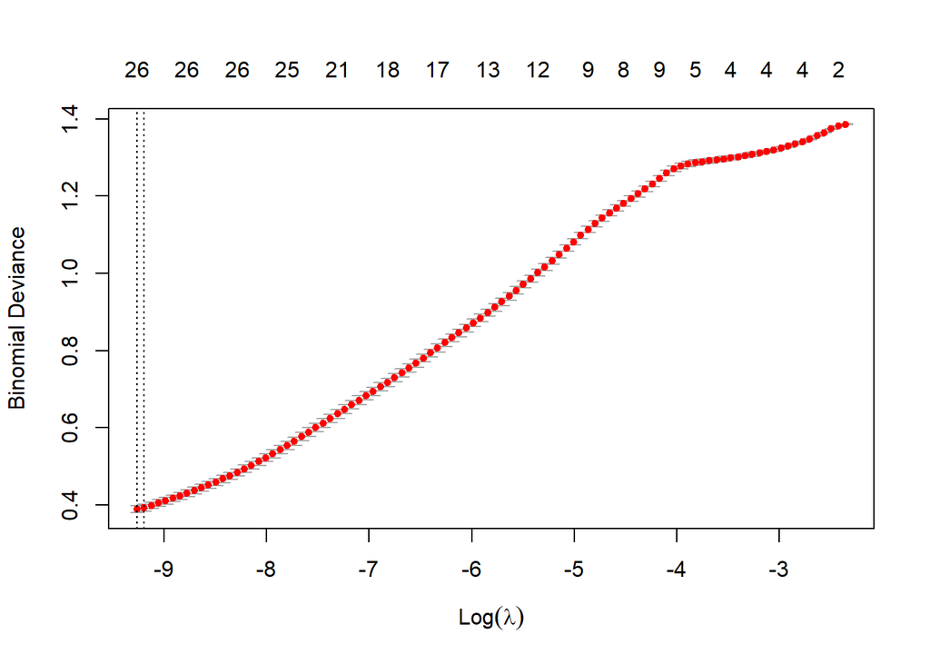

```r
# Plot the cross-validation curve to visualize lambda selection
plot(cv_lasso)
```

```r
# Step 3: Make Predictions Using the Lasso Model
# Predict probabilities on training, test, and calibration data
predictions_train <- predict(cv_lasso, s = best_lambda, newx = X_train, type = "response")
predictions_test <- predict(cv_lasso, s = best_lambda, newx = X_test, type = "response")
predictions_cal <- predict(cv_lasso, s = best_lambda, newx = X_cal, type = "response")

# Convert predicted probabilities to binary classes (0 or 1) using a threshold of 0.5
predicted_classes_train <- ifelse(predictions_train > 0.5, 1, 0)
predicted_classes_test <- ifelse(predictions_test > 0.5, 1, 0)
predicted_classes_cal <- ifelse(predictions_cal > 0.5, 1, 0)

# Step 4: Evaluate the Model with a Confusion Matrix
# Confusion matrix for the test data
confusion_matrix_test <- table(actual = y_test, predicted = predicted_classes_test)
print("Confusion Matrix (Test Data):")
```

```
## [1] "Confusion Matrix (Test Data):"
```

```r
print(confusion_matrix_test)
```

```
##       predicted
## actual   0   1
##      0 112   3
##      1   8 107
```

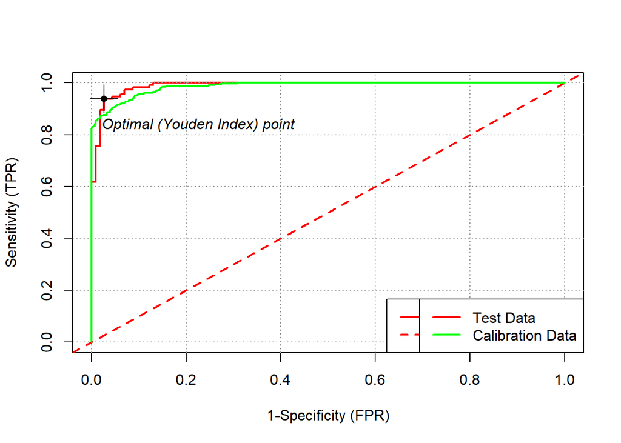

```r
# Ensure that predictions are vectors (in case they are matrices)
predictions_test <- as.vector(predictions_test)
predictions_cal <- as.vector(predictions_cal)

# Ensure that actual class labels are vectors (numeric or factor)
y_test <- as.numeric(as.character(y_test))
y_cal <- as.numeric(as.character(y_cal))

# Step 5: ROC and AUC Calculation Using ROCit for Test and Calibration Data
rocit_test_lasso <- rocit(score = predictions_test, class = y_test)
rocit_cal_lasso <- rocit(score = predictions_cal, class = y_cal)
# Step 6: Plot ROC Curves for Test and Calibration Data
plot(rocit_test_lasso, col = "red", main = "ROC Curve - Lasso Regularized Logistic Regression")
lines(rocit_cal_lasso$TPR ~ rocit_cal_lasso$FPR, col = "green", lwd = 2)
legend("bottomright", legend = c("Test Data", "Calibration Data"), col = c("red", "green"), lwd = 2)
```

```r
# Step 7: Print AUC Values for Test and Calibration Data
print(paste("AUC (Test Data):", rocit_test_lasso$AUC))
```

```
## [1] "AUC (Test Data): 0.990170132325142"
```

```r
print(paste("AUC (Calibration Data):", rocit_cal_lasso$AUC))
```

```
## [1] "AUC (Calibration Data): 0.987078923965161"
```

As mentioned previously, this is how the implemetation of regularization and we are use Lasso (L1) for this (Mount & Zumel, 2019). To start the training, test and calibration must transformed into a format suitable for cv.glmnet by creating a feature matrices and excluding the target variable only to be converted as numerical.

The we fit the model by applying L1 Regularization and also tunes the lambda parameter to minimize the cross validation. Then we check the best optimal lambda in order to do prediction. Which later be used to fine the AUC values. From the result, it is shown that model still performs the same as the second model after feature selection and the AUC values is close to 1.

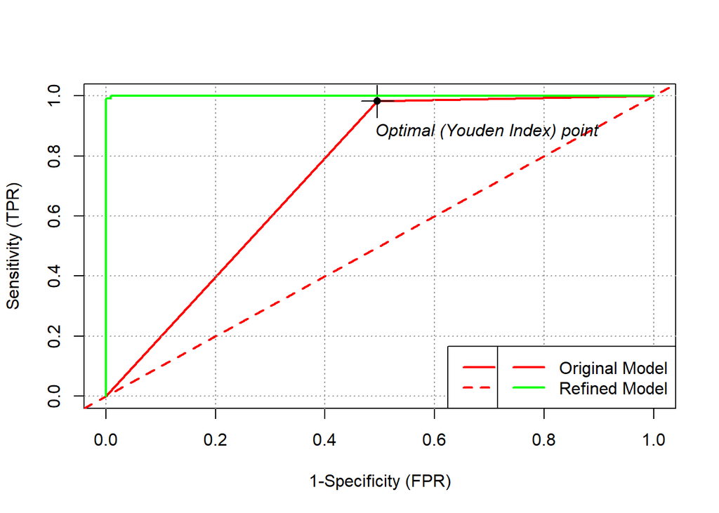

```r
# ROC and AUC for the test data from both original and refined models

# Predictions probabilities for the test data from the original and refined models
predictions_Log <- predict(logistic_model, newdata = test_data_log2, type = "response")
predictions_Log_selected <- predict(logistic_model_selected, newdata = test_data_log2_s, type = "response")

# ROC Curves using ROCit for test data
rocit_log_test <- rocit(score = predictions_Log, class = test_data_log2$Death_Rate_Class)
rocit_log_test2 <- rocit(score = predictions_Log_selected, class = test_data_log2_s$Death_Rate_Class)

# Plot ROC curves for the test data from both models
plot(rocit_log_test, col = "red", main = "ROC Curves for Test Data (Original vs Refined Model)", lwd = 2)
lines(rocit_log_test2$TPR ~ rocit_log_test2$FPR, col = "green", lwd = 2)

# Add legend to distinguish between models
legend("bottomright", legend = c("Original Model", "Refined Model"), col = c("red", "green"), lwd = 2)
```

```r
# AUC values for both models
cat("AUC for Original Model:", rocit_log_test$AUC, "\n")
```

```
## AUC for Original Model: 0.7434783
```

```r
cat("AUC for Refined Model:", rocit_log_test2$AUC, "\n")
```

```
## AUC for Refined Model: 0.9999244
```

Having said that, we proceed to the comparison of first and second model for logistic regression and looking from the performance through ROC plot and AUC values.Since the regularization model show an overfitting results. It seems that the first one shows a reasonable results and performs well although there are some imbalances since the second model is too perfect and performs too well which is too odd.

## Best model

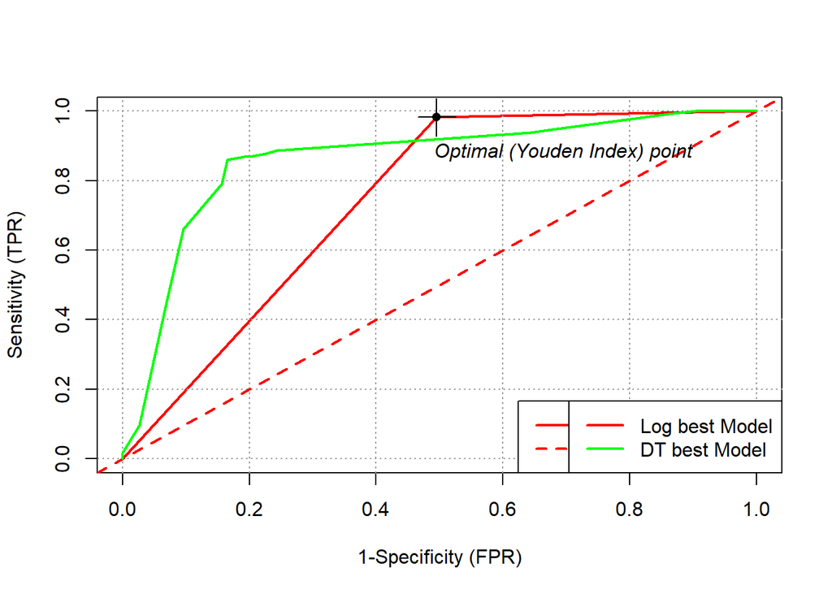

```r
# ROC and AUC for the test data from both original and refined models

# Predictions probabilities for the test data from the original and refined models
predictions_Log <- predict(logistic_model, newdata = test_data_log2, type = "response")
predictions_prob_test_refined <- predict(tree_model_threshold, newdata = test_data_selected, type = "prob")[, 2]  # Refined model

# ROC Curves using ROCit for test data
rocit_log_test <- rocit(score = predictions_Log, class = test_data_log2$Death_Rate_Class)
rocit_test_refined <- rocit(score = predictions_prob_test_refined, class = test_data_selected$Death_Rate_Class)

# Plot ROC curves for the test data from both models
plot(rocit_log_test, col = "red", main = "ROC Curves for Test Data (Log best vs DT best)", lwd = 2)
lines(rocit_test_refined$TPR ~ rocit_test_refined$FPR, col = "green", lwd = 2)

# Add legend to distinguish between models
legend("bottomright", legend = c("Log best Model", "DT best Model"), col = c("red", "green"), lwd = 2)
```

```r
# AUC values for both models
cat("AUC for Log best Model:", rocit_log_test$AUC, "\n")
```

```
## AUC for Log best Model: 0.7434783
```

```r
cat("AUC for DT best Model:", rocit_test_refined$AUC, "\n")
```

```
## AUC for DT best Model: 0.8615879
```

The final step is to select the best model by comparing the two best models for each classifier and assessing how well they perform on the test data. The ROC curve and AUC (Area Under the Curve) are the metrics used in the main comparison. These criteria aid in identifying the model that performs best at class distinction.

The Decision Tree model’s AUC value of 0.8616 shows that it can effectively distinguish between the two classes (High and Low death rates). However, compared to the Decision Tree, the Logistic Regression model performs less well in class differentiation, as evidenced by its lower AUC of 0.7435.

The Decision Tree model performs better in predicting the death rate class with greater accuracy and resilience, as evidenced by these AUC values, making it the superior classifier in this comparison. As a result, the Decision Tree model would be chosen as the project’s final model.

## LIME explainer

```r
# Load necessary library
# Step 1: Ensure necessary libraries are loaded
library(lime)
```

[figure not shown]

```r
# Step 2: Define the model_type and predict_model functions
model_type.glm <- function(x, ...) {
  return("classification")
}

predict_model.glm <- function(x, newdata, ...) {
  preds <- predict(x, newdata = newdata, type = "response")
  return(as.data.frame(cbind(1 - preds, preds)))  # Return probabilities
}

model_type.rpart <- function(x, ...) {
  return("classification")
}

predict_model.rpart <- function(x, newdata, ...) {
  preds <- predict(x, newdata = newdata, type = "prob")
  return(as.data.frame(preds))  # Return probabilities
}

# Create LIME explainers
explainer_log <- lime(train_data_log, logistic_model)
explainer_dt <- lime(train_data_selected, tree_model_threshold)
# Run explain function
explanation_dt <- explain(test_data_selected[1:5, ], explainer_dt, n_labels = 1, n_features = 5)
explanation_log <- explain(test_data_log2[1:5, ], explainer_log, n_labels = 1, n_features = 5)

#Plot the explanations
plot_features(explanation_log)
```

[figure not shown]

```r
plot_features(explanation_dt)
```

This part is where the two model from Decision Tree and Logistic regression will be explained with LIME.The aim here is to interpret and explain the predictions.Also,the focus was on understanding how individual features contribute to the predictions.

Here we used the best model from the two classifiers components and and use the explainer() to explain the features from two best models.Using these explainers, we generated explanations for the top 5 features influencing the predictions of the first 5 cases in the test datasets.

For instance in Logistic Regression,The most significant determinants of predictions are Population, Unsafe.water.source, and Household.air.pollution in case 39. The degree to which the chosen features adequately explain the model’s choice is shown by the explanation fit, which varies between situations and has values between 0.254 and 0.044. Features that support the anticipated class are represented by blue bars, and those that contradict it are shown by red bars.

By comparing the two models, we gained insights into how the features influence the predictions differently. Logistic regression offers linear interpretability, while the decision tree provides a more complex, non-linear understanding of feature importance.

# Clustering (k-means)

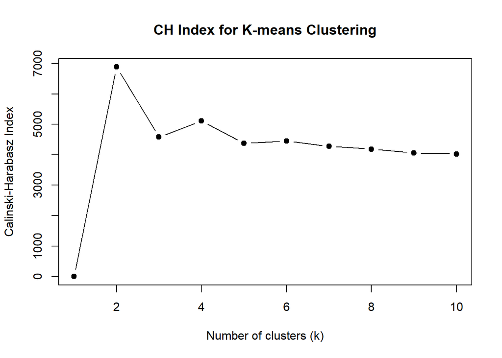

```r
# Load necessary libraries
library(ggplot2)
library(fpc)         # For kmeansruns() and clustering
library(factoextra)   # For PCA and cluster visualization
library(gridExtra)    # For arranging multiple plots
# Assuming 'data' is already loaded, select relevant numerical features for clustering
numerical_columns <- names(merged_data3)[sapply(merged_data3, is.numeric)]

# Exclude 'Death_Proxy_Proportion' from the numerical columns
numerical_columns <- setdiff(numerical_columns, c("Death_Rate_Proxy","Death_Proxy_Proportion","Death_Rate_Class"))

# Select the relevant numerical data for clustering
data_clustering <- merged_data3[, numerical_columns]

data_clustering_scaled <- scale(data_clustering)

# Step 2: Investigating Optimal Number of Clusters ------------------------

# Use kmeansruns() from the fpc package to determine the best number of clusters using CH Index
set.seed(123)  # Ensure reproducibility
kmeans_result_ch <- kmeansruns(data_clustering_scaled, krange = 1:10, criterion = "ch")

# Plot the CH Index results to identify the optimal k
ch<-plot(kmeans_result_ch$crit, type = "b", pch = 19,
     xlab = "Number of clusters (k)",
     ylab = "Calinski-Harabasz Index",
     main = "CH Index for K-means Clustering")
```

```r
# Print the suggested optimal number of clusters based on the CH Index
optimal_k_ch <- kmeans_result_ch$bestk
cat("Optimal number of clusters based on CH Index:", optimal_k_ch, "\n")
```

```
## Optimal number of clusters based on CH Index: 2
```

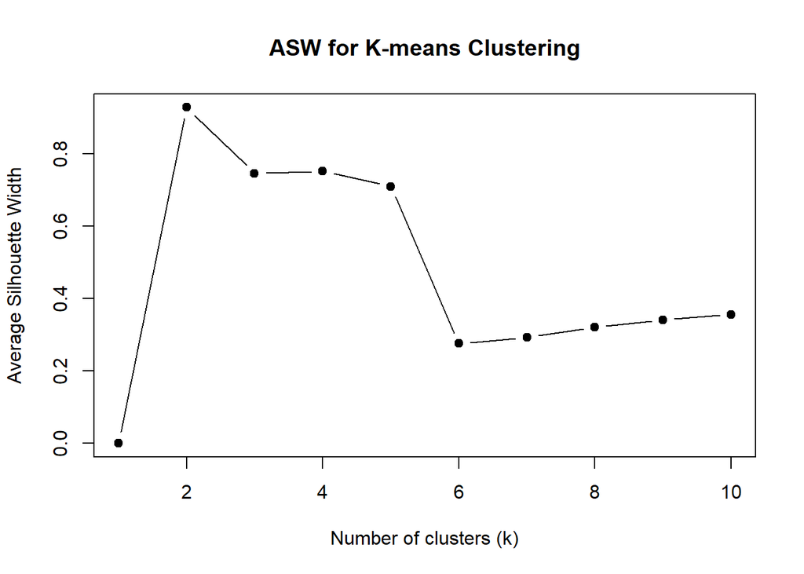

```r
# Use Average Silhouette Width (ASW) to compare
kmeans_result_asw <- kmeansruns(data_clustering_scaled, krange = 1:10, criterion = "asw")

# Plot the ASW results to identify the optimal k
asw<-plot(kmeans_result_asw$crit, type = "b", pch = 19,
     xlab = "Number of clusters (k)",
     ylab = "Average Silhouette Width",
     main = "ASW for K-means Clustering")
```

```r
# Print the suggested optimal number of clusters based on ASW
optimal_k_asw <- kmeans_result_asw$bestk
cat("Optimal number of clusters based on ASW:", optimal_k_asw, "\n")
```

```
## Optimal number of clusters based on ASW: 2
```

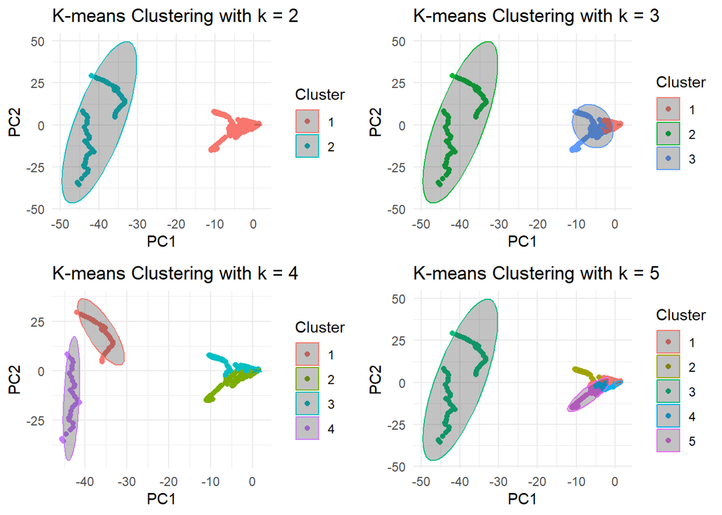

```r
# Perform PCA for visualization purposes (reduces dimensionality to 2D)
pca_result <- prcomp(data_clustering_scaled)

# Function to visualize K-means clustering results for any number of clusters k
visualize_kmeans <- function(data_scaled, k, pca_result) {
  # Perform K-means clustering with the specified number of clusters
  set.seed(123)
  kmeans_model <- kmeans(data_scaled, centers = k, nstart = 20)
  # Create a data frame for the PCA results
  pca_df <- data.frame(PC1 = pca_result$x[, 1], PC2 = pca_result$x[, 2])
  # Add the cluster assignments from K-means
  pca_df$Cluster <- as.factor(kmeans_model$cluster)
  # Create the plot
  plot_kmeans <- ggplot(pca_df, aes(PC1, PC2, color = Cluster)) +
    geom_point() +
    stat_ellipse(geom = "polygon", alpha = 0.3) +
    labs(title = paste("K-means Clustering with k =", k)) +
    theme_minimal()
  # Return the plot
  return(plot_kmeans)
}

# Step 5: Visualize Clustering Results with grid.arrange() ----------------

# Visualize for k = 2 ,3 ,4, 5
plot_k2 <- visualize_kmeans(data_clustering_scaled, k = 2, pca_result)
plot_k3 <- visualize_kmeans(data_clustering_scaled, k = 3, pca_result)
plot_k4 <- visualize_kmeans(data_clustering_scaled, k = 4, pca_result)
plot_k5 <- visualize_kmeans(data_clustering_scaled, k = 5, pca_result)

# Arrange the plots in a 2x2 grid for comparison
grid.arrange(plot_k2, plot_k3, plot_k4, plot_k5, nrow = 2)
```

In Clustering, K-means is used on the given dataset.To start,we need to scale the data first and exclude the non-numerical variable as the represent a catergorical variable and target variable.

The Second step there are two methods to determine the optimal numbers of k which is the Calinski-Harabasz Index (CH) and the Average Silhouette Width (ASW).How CH works is based on the variance ratio, aiming to maximize the distance between clusters while minimizing the distance within clusters whereas ASW evaluates how similar an object is to its own cluster compared to other clusters, providing a measure of cluster cohesion and separation.

after running the kmeans based on those two methods. CH and ASW get the same optimal value of 2.Using the optimal number of k, we need to visualize it and showing the data into groupn of clusters of 2,3,4,5.

When visualizing clustering for k = 2, the two clusters are clearly distinct, indicating significant differences in the feature values, such as GDP and population, between the two groups. This suggests the data represents two different types of countries or regions. However, as the number of clusters increases (e.g., k = 3, 4, 5), the clusters become less distinct and begin to overlap. Forcing more clusters results in over-clustering, where the additional clusters don’t provide meaningful separation, reducing the insight gained from the data.

# References

Foster, S. (1998, July 20). Tokelau | Polynesian Territory, New Zealand. Encyclopedia Britannica. https://www.britannica.com/place/Tokelau

Heaton, P., & Rushe, G. J. (2024, October 3). Bermuda | Geography, History, & Facts. Encyclopedia Britannica. https://www.britannica.com/place/Bermuda

List of countries by continent 2024. (n.d.). https://worldpopulationreview.com/country-rankings/list-of-countries-by-continent

Mount, J., & Zumel, N. (2019). Practical Data Science with R, Second Edition. Simon and Schuster.

rnaturalearth package - RDocumentation. (n.d.). https://www.rdocumentation.org/packages/rnaturalearth/versions/1.0.1

varImp function - RDocumentation. (n.d.). https://www.rdocumentation.org/packages/modEvA/versions/3.18.2/topics/varImp